# Projet CNRT Mines et Territoire

THION Romuald, UNC

Décembre 2022

# Evolution du niveau d’équipement des ménages NC et l’influence de la mine.

Cette étude porte sur le Niveau d’Equipement des Ménages (**NEM**) sur les Bases Individuelles (**BI**) et les Bases Logements (**BL**) du Recensement de la Population (**RP**) de Nouvelle-Calédonie (NC) sur les années 2009, 2014 et 2019. Cette étude est réalisé par THION Romuald, maître de conférences en informatique à l’UNC, dans les locaux de l’ISEE dans le cadre du projet CNRT *Mine et Territoires* (**M&T**).

## Sources de données

Les sources de données suivantes sont utilisées dans cette étude :

- `src-iris/` : le shapefile des IRIS UNC09-14-19 créé par l’ISEE pour le projet M&T.
- `src-communes/` : les limites administratives terrestres (BDADMIN-NC) des communes, [source](https://georep-dtsi-sgt.opendata.arcgis.com/maps/limites-administratives-terrestres-1/about). Le shapefile est chargé en SQL et enrichi avec l’information du type de site retenu dans le projet M&T (*centre*, *usine/métallurgique* ou *témoin*). Un export CSV `communes.csv` permet d’avoir les noms correctement encodés.
- `src-desserte/` : le calcul à partir de la BDROUTE-NC de la durée minimale/moyenne/médiane maximale à chacun des sites miniers, voir rapport technique consacré dans les livrables du projet. Les données sont ré-exportées dans le fichier `duree-iris.csv` dans un format utilisable facilement en R.
- `src-rp/` : les BI et BL des RP 2009, 2014 et 2019 accompagnés de leurs dictionnaires de données fournis par l’ISEE. La conversion du format `dbf` dans le format `csv` est réalisée par le script `export_dbf_to_csv.R` à exécuter une fois pour toutes.

On charge le dictionnaire des communes et des IRIS pour avoir leurs noms correctement orthographiés.

Ensuite on charge les BL des trois années, en ne gardant :

- que les logements qui sont des **résidences principales** (`CATL == 1`),
- que les ménages qui sont **hors du Grand Nouméa** (`NC %notin% grand_noumea`).

On remarque de filtrer hors du GN a un effet très limité sur les évolutions (sauf en valeur absolue de variation des écart-types) mais améliore la qualité des regressions.

On crée également la clef de jointure `IDLOG` entre la BI et la BL comme la concaténation des variables suivantes, dans l’ordre :

- `NC` : numéro de la commune (de 01 à 33),
- `DIST` : code ilot / district. C’est l’unité géographique de référence de l’ISEE. On utilisera plutôt la commune et un IRIS intermédiaire entre commune et îlot créé pour le projet, appelé `IRIS` ou `IRISUNC`
- `RADR` : rang de la construction, rang de l’adresse.
- `RLOG` : rang de logement.

Si les questionnaires des RP 2009, 2014 et 2019 sont très similaires, certaines modalités changent néanmoins, dont notamment dans la BL 2019 :

- la variable `BATI` en 2019, les anciennes modalités 2009 et 2009 sont disponibles dans la variable `TYPC14`.
- la variable `DIPLM` en 2019, les anciennes modalités 2009 et 2009 sont disponibles dans la variable `DIPLM14`.

On note qu’à ce stade, on ne se sert pas encore des BI. In fine, les trois BL contiennent :

- 22090 logements d’intérêt en 2009 décrits par 70 variables,
- 25477 logements d’intérêt en 2014 décrits par 73 variables,
- 27613 logements d’intérêt en 2019 décrits par 76 variables.

## Calcul du NEM

On reprend la méthodologie générale des études socio-énonomiques précédemment réalisées dans le volet A du projet M&T dans les stages d’Elise, Alban et Heloise. Ces travaux s’appuyent entres autres sur un indicateur de *niveau d’équipement des ménages*, abrégé **NEM**, construit à partir des variables d’équipements disponibles dans la BL.

### Codage des modalités

La première étape est le traitement des **14 variables catégorielles d’équipement des ménages**. On doit adapter le codage utilisés précédement pour les RP 2009 et 2014 :

- les variables `TMOB`, `ORDI` ne sont plus présentes dans la BL 2019.
- certaines modalités comme `ELEC` on changé en 2019.
- la variable `MAL` présente sur les 3 RP a été ajoutée.
- le codage des variables `VOIT`, `BATO`, `DEROU` a été modifié
  - il a été binarisé, pour le rendre homogène avec les autres, alors qu’il était précédement codé sur 4 valeurs,
  - on s’appuie sur le nombre d’actifs du logement (`INPAM`) et plus le nombre de personnes majeurs, ce qui évite une jointure avec la BI,

Il y a un questionnement général sur **l’influence du codage sur les résultats d’analyses** et la validité des conclusions *si on adopte un codage similaire mais différent*.

Le codage est encapsulé dans la fonction `codage_modalites_bl` qui va créer un nouveau *dataframe* Cette fonction transforme 14 variables catégorielles d’équipement en variables binaires. Sauf précision, il n’y a que deux modalités *1 : équipé* et *2 : non équipé* pour les 14 variables suivantes qui sont agrégés dans le NEM :

- `ELEC`: mode principal d’éclairage. (RP09/14 : 1 = réseau général, 3 = panneaux. RP19 : 1 = raccordé, 2 = non). Par cohérence entre années, on ne garde que la modalité 1;
- `EAU` : alimentation principale en eau du logement. (RP09/14/19 : 1 = eau courante);
- `BATI` : type de logement, 1 ssi le type est *maison* (1) ou *appartement* (2), les autres valeurs valant 0;
- `BAIN` : baignoire ou douche (variables `IS` dans les données 2009 et 2014 de P. Rivoilant);
- `WC` : équipement en WC;
- `MAL` : machine à laver;
- `REFRI` : réfrigérateur;
- `CLIM` : équipement du logement en climatisation;
- `CHOS` : équipement du logement en chauffe-eau solaire;
- `TFIXE` : téléphone fixe;
- `INTER` : accès internet;
- `VOIT` : nombre de voitures, 1 ssi le nombre de véhicules est supérieur ou égal au nombre d’actifs;
- `BATO` : nombre de bateaux, 1 ssi le nombre de véhicules est supérieur ou égal au nombre d’actifs;
- `DEROU` : nombre de deux-roues motorisés, 1 ssi le nombre de véhicules est supérieur ou égal au nombre d’actifs.

```r
codage_modalites_bl <- function(src) {
  # on garde les variables suppl d'intérêt
  base <- src %>%
    select(IDLOG, IRISUNC, NC, PROV, CS8M, DIPLM, AGERM)
  # on construit les 14 variables binaires
  base$ELEC <- as.numeric(src$ELEC == 1)
  base$EAU <- as.numeric(src$EAU == 1)
  base$BATI <- as.numeric(src$BATI %in% c(1, 2))
  base$BAIN <- as.numeric(src$BAIN == 1)
  base$WC <- as.numeric(src$WC == 1)
  base$MAL <- as.numeric(src$MAL == 1)
  base$REFRI <- as.numeric(src$REFRI == 1)
  base$CLIM <- as.numeric(src$CLIM == 1)
  base$CHOS <- as.numeric(src$CHOS == 1)
  base$TFIXE <- as.numeric(src$TFIXE == 1)
  base$INTER <- as.numeric(src$INTER == 1)
  base$VOIT <- as.numeric(src$INPAM <= src$VOIT)
  base$BATO <- as.numeric(src$INPAM <= src$BATO)
  base$DEROU <- as.numeric(src$INPAM <= src$DEROU)
  return(base)
}
```

On applique cette transformation et on ne garde que le sous-ensemble des 14 variables d’équipement d’intérêt et des cofacteurs d’analyse, soit :

- le code d’IRIS (variable `IRISUNC`),
- le numéro de commune (variable `NC`)
- la province (variable `PROV`)
- la CSP sur 8 postes de la personne de référence du ménage (variable `CS8M`)
- le diplôme de la personne de référence du ménage (variable `DIPLM`)
- l’age révolu de la personne de référence du ménage (variable `AGERM`)
- on garde aussi `IDLOG` pour la jointure avec la BI.

### Calcul des poids du NEM

On va maintenant calculer le NEM avec le poids de chacune des variables d’équipement grâce aux 5 premières dimensions d’une ACP. Ce calcul est refait pour chacun des RP 2009, 2014 et 2019. Pour le chargement dans QGIS, on crée *manuellement* un fichier `.csvt` éponyme qui contient les types des colonnes.

On a des *variation substantielles* des coefficients selon le codage choisi avec ka fonction `codage_modalites_bl`. On affiche ci-dessous le résultat enregistré dans le fichier `output/nem_weights.csv`.

```
##       Y2009 Y2014 Y2019
## ELEC   7.00  7.54  7.74
## EAU    5.24  8.87  8.11
## BATI  10.19  4.49  5.01
## BAIN   9.09  8.40  8.28
## WC     9.01  8.60  8.48
## MAL    6.38  6.59  6.54
## REFRI  7.57  8.09  8.03
## CLIM   5.56  5.89  6.00
## CHOS   4.11  4.34  4.02
## TFIXE  5.84  6.03  6.51
## INTER  6.45  6.69  6.57
## VOIT   5.88  6.05  6.11
## BATO   8.87  9.24  9.34
## DEROU  8.81  9.18  9.26
```

### Agrégation du NEM par IRIS

On crée un *dataframe* avec les valeurs agrégées du NEM par IRIS, on donne ici 7 indicateurs pour chaque IRIS et chaque année :

- le **nombre** de logements,
- la **somme**, la **moyenne** et l’**écart-type** du NEM,
- la **somme**, la **moyenne** et l’**écart-type** du NEM base 100 NC,

On fait la jointure en post-fixant les années et on exporte le tout dans le fichier `output/nem_iris.cs` avec son compagnon `.csvt` qui contient les types (pour QGIS). On obtient un fichier résultat comme suit avec 22 colonnes (3 années x 7 attributs plus le code IRIS) qui constitue *le matériel de base pour la suite de l’étude*.

```
## # A tibble: 80 × 22
##    IRISUNC COUNT_09 NEM_SUM_09 NEM_MEA…¹ NEM_S…² NEM10…³ NEM10…⁴ NEM10…⁵ COUNT…⁶ NEM_S…⁷ NEM_M…⁸ NEM_S…⁹ NEM10…˟ NEM10…˟ NEM10…˟ COUNT…˟ NEM_S…˟
##    <chr>      <int>      <dbl>     <dbl>   <dbl>   <dbl>   <dbl>   <dbl>   <int>   <dbl>   <dbl>   <dbl>   <dbl>   <dbl>   <dbl>   <int>   <dbl>
##  1 0101         173      5582.      32.3    16.2  10620.    61.4    30.8     181   9121.    50.4    15.0  15166.    83.8    25.0     199  11174.
##  2 0201         434     30614.      70.5    16.7  58240.   134.     31.9     502  37403.    74.5    17.3  62191.   124.     28.8     730  55315.
##  3 0204         189     11992.      63.4    19.9  22813.   121.     37.8     351  22564.    64.3    18.1  37517.   107.     30.1     331  21481.
##  4 0205         162      7637.      47.1    18.4  14529.    89.7    35.0     164   8225.    50.1    15.3  13675.    83.4    25.4     179  10214.
##  5 0301         542     37683.      69.5    15.4  71689.   132.     29.3     621  44697.    72.0    14.9  74319.   120.     24.7     608  43416.
##  6 0302         332     23174.      69.8    17.4  44086.   133.     33.1     431  31626.    73.4    14.7  52586.   122.     24.4     472  35839.
##  7 0303          39      2548.      65.3    18.8   4847.   124.     35.7      57   3958.    69.4    13.8   6581.   115.     22.9      42   2910.
##  8 0304         355     24475.      68.9    16.2  46561.   131.     30.8     446  31638.    70.9    15.8  52605.   118.     26.3     519  37132.
##  9 0305         292     12585.      43.1    17.9  23942.    82.0    34.0     282  15051.    53.4    15.4  25026.    88.7    25.7     267  15489.
## 10 0401         452     20452.      45.2    17.6  38908.    86.1    33.5     511  27936.    54.7    14.5  46450.    90.9    24.0     511  29606.
## # … with 70 more rows, 5 more variables: NEM_MEAN_19 <dbl>, NEM_SD_19 <dbl>, NEM100_SUM_19 <dbl>, NEM100_MEAN_19 <dbl>, NEM100_SD_19 <dbl>, and
## #   abbreviated variable names ¹NEM_MEAN_09, ²NEM_SD_09, ³NEM100_SUM_09, ⁴NEM100_MEAN_09, ⁵NEM100_SD_09, ⁶COUNT_14, ⁷NEM_SUM_14, ⁸NEM_MEAN_14,
## #   ⁹NEM_SD_14, ˟NEM100_SUM_14, ˟NEM100_MEAN_14, ˟NEM100_SD_14, ˟COUNT_19, ˟NEM_SUM_19
```

## Contributions des variables du NEM

Dans cette section, on va vérifier la validité de l’indicateur NEM en le comparant aux co-facteurs socio-énconomiques des individus (soit les personnes de référence des ménages, soient les individus de la BI).

### Correlations intervariables

On va aggréger sur les IRIS et ensuite afficher le *corrélogramme* des 14 variables.

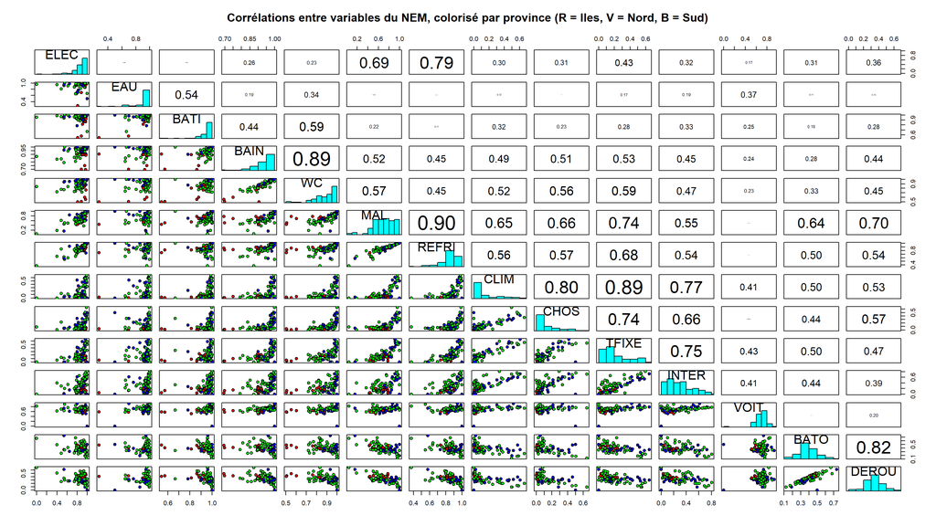

On apprécie ici les fortes corrélations dans les attributs :

- dans les équipements de base :
  - `WC` et `BAIN`
  - `MAL` et `FRIGO` avec `ELEC`
- dans les équipements supérieurs :
  - très forte entre `CLIM`, `TFIXE` et `INTER` puis `CHOS` dans un second temps
- dans la mobilité :
  - entre `BATO` et `DEROU`

A l’inverse, on voit l’indépendance de `VOIT`.

### ACP de l’équipement des ménages par commune

On fait une analyse PCA directement sur les 14 variables d’équipement qui constituent le NEM sur la BL 2019, qu’on agrège par commune pour que le graphe soit plus lisible.

```
##               ELEC   EAU  BATI  BAIN    WC   MAL REFRI   CLIM   CHOS  TFIXE  INTER  VOIT  BATO DEROU  NEM NEM100 COUNT
## Belep        0.930 0.985 0.864 0.920 0.854 0.372 0.789 0.0151 0.0854 0.0653 0.2261 0.588 0.613 0.573 56.2   90.6   199
## Boulouparis  0.886 0.911 0.977 0.984 0.978 0.876 0.924 0.4476 0.3516 0.4234 0.4806 0.773 0.433 0.365 70.2  113.2  1240
## Bourail      0.946 0.975 0.981 0.976 0.979 0.886 0.947 0.4376 0.3386 0.5204 0.5314 0.743 0.327 0.303 70.6  114.0  1908
## Canala       0.856 0.970 0.950 0.929 0.909 0.576 0.793 0.0537 0.0461 0.1234 0.1714 0.674 0.402 0.352 55.6   89.8  1062
## Farino       0.969 0.966 1.000 1.000 1.000 0.954 0.989 0.3027 0.2146 0.5211 0.5096 0.885 0.425 0.349 71.9  116.1   261
## Hienghène    0.714 0.956 0.982 0.909 0.838 0.498 0.788 0.0368 0.0663 0.1546 0.3756 0.686 0.467 0.433 56.5   91.3   679
## Houailou     0.875 0.976 0.969 0.925 0.892 0.695 0.842 0.0495 0.0586 0.1997 0.2096 0.680 0.426 0.372 58.3   94.1  1212
## Ile des Pins 0.958 0.935 0.924 0.902 0.855 0.629 0.775 0.0318 0.0666 0.1710 0.1437 0.554 0.369 0.352 54.8   88.4   661
## Kaala Gomen  0.913 0.876 0.957 0.948 0.898 0.781 0.941 0.1815 0.1593 0.2556 0.3444 0.778 0.344 0.250 61.7   99.6   540
## Koné         0.951 0.977 0.987 0.987 0.983 0.896 0.952 0.3927 0.4015 0.4047 0.5726 0.742 0.206 0.175 68.8  111.0  2508
## Koumac       0.963 0.957 0.973 0.989 0.978 0.918 0.959 0.5174 0.2880 0.4664 0.5089 0.740 0.275 0.213 69.7  112.5  1295
## La Foa       0.934 0.932 0.961 0.982 0.975 0.885 0.958 0.4120 0.2615 0.4128 0.4517 0.760 0.373 0.302 68.6  110.6  1262
## Lifou        0.915 0.966 0.912 0.910 0.839 0.734 0.869 0.0601 0.0230 0.2171 0.2082 0.668 0.378 0.373 57.7   93.1  2695
## Maré         0.961 0.955 0.893 0.798 0.662 0.742 0.858 0.0228 0.0260 0.0898 0.1184 0.655 0.444 0.448 54.8   88.4  1537
## Moindou      0.907 0.974 0.981 0.970 0.981 0.851 0.929 0.2015 0.2127 0.3657 0.3918 0.795 0.440 0.384 67.0  108.1   268
## Ouégoa       0.843 0.947 0.958 0.934 0.858 0.606 0.789 0.1511 0.1118 0.1329 0.1798 0.722 0.485 0.364 57.7   93.1   662
## Ouvéa        0.886 0.742 0.699 0.843 0.669 0.519 0.803 0.0196 0.0310 0.0610 0.1550 0.546 0.401 0.389 48.4   78.2   968
## Poindimié    0.920 0.966 0.957 0.951 0.870 0.654 0.869 0.0991 0.1120 0.2098 0.5084 0.736 0.441 0.429 62.4  100.6  1544
## Ponérihouen  0.874 0.946 0.926 0.895 0.846 0.595 0.831 0.0324 0.0811 0.1270 0.3297 0.727 0.503 0.485 58.5   94.5   740
## Pouébo       0.934 0.971 0.923 0.951 0.908 0.602 0.862 0.0303 0.0403 0.0874 0.0874 0.691 0.534 0.461 57.7   93.2   595
## Pouembout    0.939 0.980 0.994 0.992 0.996 0.922 0.960 0.5026 0.4470 0.4795 0.6884 0.757 0.191 0.158 71.5  115.3   953
## Poum         0.792 0.672 0.927 0.842 0.762 0.490 0.692 0.0878 0.0707 0.1734 0.1820 0.610 0.495 0.313 50.8   82.0   467
## Poya         0.865 0.928 0.975 0.961 0.956 0.769 0.883 0.2618 0.1309 0.2905 0.3927 0.729 0.356 0.281 62.7  101.2   871
## Sarraméa     0.934 0.969 0.990 0.990 0.990 0.714 0.893 0.1224 0.1531 0.2806 0.3112 0.745 0.342 0.296 62.5  100.9   196
## Thio         0.867 0.930 0.959 0.960 0.905 0.672 0.825 0.0988 0.0951 0.1704 0.1716 0.621 0.360 0.277 56.5   91.2   810
## Touho        0.902 0.993 0.975 0.943 0.865 0.649 0.847 0.0843 0.1036 0.1975 0.5525 0.709 0.448 0.392 62.0  100.0   724
## Voh          0.898 0.973 0.965 0.963 0.920 0.824 0.920 0.2673 0.2094 0.2517 0.5445 0.725 0.308 0.234 64.2  103.7   898
## Yaté         0.742 0.965 0.969 0.960 0.938 0.839 0.896 0.0265 0.0618 0.1435 0.1038 0.620 0.322 0.260 56.0   90.4   453
## Kouaoua      0.800 0.970 0.980 0.968 0.931 0.731 0.842 0.1556 0.0370 0.1728 0.2815 0.689 0.286 0.252 57.7   93.1   405
```

On remarque la position de Pouembout, Koné et Koumac à droite du premier axe et accompagnés des communes de la côte ouest de la NC. Les communes de la province des îles, de la côte est et du Nord sont au contraire plutôt à gauche. Ces deux premières dimensions capturent respectivement 60.1% et 11.6% de la variance. Pour le NEM on utilise les 5 premières dimensions qui capturent au total 91.3% de la variance. Si on ajoute le Grand Nouméa dans le calcul du NEM, ses communes se trouveraient à droite, sans surprise.

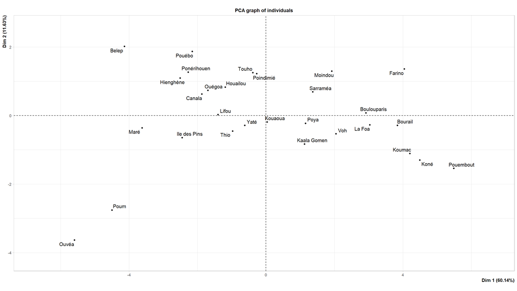

On affiche le résumé de l’analyse avec les contributions de toutes les communes et toutes les variables d’équipement.

```
##
## Call:
## PCA(X = df_communes %>% select(-NEM, -NEM100, -COUNT), graph = FALSE)
##
##
## Eigenvalues
##                        Dim.1   Dim.2   Dim.3   Dim.4   Dim.5   Dim.6   Dim.7   Dim.8   Dim.9  Dim.10  Dim.11  Dim.12  Dim.13  Dim.14
## Variance               8.420   1.628   1.384   0.862   0.489   0.423   0.300   0.223   0.099   0.068   0.053   0.022   0.018   0.012
## % of var.             60.141  11.627   9.886   6.156   3.491   3.024   2.141   1.592   0.707   0.489   0.382   0.156   0.125   0.083
## Cumulative % of var.  60.141  71.768  81.654  87.810  91.301  94.325  96.466  98.058  98.765  99.254  99.636  99.792  99.917 100.000
##
## Individuals
##                  Dist    Dim.1    ctr   cos2    Dim.2    ctr   cos2    Dim.3    ctr   cos2
## Belep        |  5.300 | -4.136  7.007  0.609 |  2.019  8.634  0.145 |  1.640  6.703  0.096 |
## Boulouparis  |  3.627 |  2.919  3.489  0.648 |  0.081  0.014  0.001 |  0.713  1.268  0.039 |
## Bourail      |  4.075 |  3.837  6.030  0.887 | -0.285  0.172  0.005 |  0.882  1.940  0.047 |
## Canala       |  2.437 | -1.874  1.438  0.591 |  0.628  0.835  0.066 | -1.125  3.154  0.213 |
## Farino       |  4.794 |  4.040  6.684  0.710 |  1.362  3.928  0.081 |  1.316  4.317  0.075 |
## Hienghène    |  4.031 | -2.510  2.581  0.388 |  1.096  2.543  0.074 | -1.822  8.266  0.204 |
## Houailou     |  1.728 | -1.192  0.582  0.476 |  0.833  1.469  0.232 | -0.585  0.852  0.114 |
## Ile des Pins |  3.378 | -2.447  2.452  0.525 | -0.643  0.877  0.036 |  0.121  0.036  0.001 |
## Kaala Gomen  |  2.127 |  1.122  0.516  0.278 | -0.830  1.459  0.152 |  0.077  0.015  0.001 |
## Koné         |  4.843 |  4.491  8.261  0.860 | -1.297  3.563  0.072 |  0.000  0.000  0.000 |
## Koumac       |  4.465 |  4.201  7.227  0.885 | -1.105  2.588  0.061 |  0.546  0.744  0.015 |
## La Foa       |  3.262 |  3.030  3.761  0.863 | -0.269  0.153  0.007 |  0.788  1.549  0.058 |
## Lifou        |  2.046 | -1.401  0.804  0.469 |  0.028  0.002  0.000 |  0.352  0.308  0.030 |
## Maré         |  5.042 | -3.617  5.358  0.515 | -0.357  0.270  0.005 |  2.051 10.476  0.165 |
## Moindou      |  2.589 |  1.923  1.514  0.552 |  1.300  3.578  0.252 |  0.465  0.538  0.032 |
## Ouégoa       |  2.366 | -1.696  1.178  0.514 |  0.737  1.152  0.097 | -0.645  1.038  0.074 |
## Ouvéa        |  7.161 | -5.594 12.818  0.610 | -3.631 27.933  0.257 |  1.977  9.740  0.076 |
## Poindimié    |  1.891 | -0.272  0.030  0.021 |  1.223  3.169  0.418 |  0.740  1.363  0.153 |
## Ponérihouen  |  2.896 | -2.274  2.119  0.617 |  1.266  3.398  0.191 |  0.707  1.244  0.060 |
## Pouébo       |  3.284 | -2.155  1.902  0.431 |  1.871  7.418  0.325 |  0.627  0.981  0.036 |
## Pouembout    |  5.853 |  5.486 12.325  0.879 | -1.539  5.018  0.069 |  0.067  0.011  0.000 |
## Poum         |  6.171 | -4.501  8.297  0.532 | -2.757 16.096  0.200 | -0.705  1.240  0.013 |
## Poya         |  1.555 |  1.156  0.547  0.552 | -0.224  0.106  0.021 | -0.774  1.494  0.248 |
## Sarraméa     |  2.116 |  1.365  0.763  0.416 |  0.692  1.013  0.107 | -0.526  0.689  0.062 |
## Thio         |  2.093 | -0.974  0.389  0.217 | -0.450  0.429  0.046 | -1.371  4.681  0.429 |
## Touho        |  2.063 | -0.382  0.060  0.034 |  1.256  3.340  0.370 |  0.226  0.127  0.012 |
## Voh          |  2.443 |  2.043  1.710  0.699 | -0.531  0.597  0.047 | -0.327  0.266  0.018 |
## Yaté         |  3.669 | -0.620  0.157  0.029 | -0.287  0.174  0.006 | -2.999 22.402  0.668 |
## Kouaoua      |  2.606 |  0.034  0.000  0.000 | -0.187  0.074  0.005 | -2.417 14.559  0.860 |
##
## Variables
##                 Dim.1    ctr   cos2    Dim.2    ctr   cos2    Dim.3    ctr   cos2
## ELEC         |  0.393  1.836  0.155 |  0.042  0.106  0.002 |  0.768 42.606  0.590 |
## EAU          |  0.427  2.166  0.182 |  0.700 30.119  0.490 | -0.091  0.597  0.008 |
## BATI         |  0.688  5.616  0.473 |  0.384  9.066  0.148 | -0.461 15.367  0.213 |
## BAIN         |  0.844  8.470  0.713 |  0.268  4.406  0.072 | -0.233  3.913  0.054 |
## WC           |  0.856  8.706  0.733 |  0.276  4.684  0.076 | -0.259  4.852  0.067 |
## MAL          |  0.894  9.482  0.798 | -0.138  1.172  0.019 |  0.031  0.069  0.001 |
## REFRI        |  0.886  9.314  0.784 |  0.047  0.134  0.002 |  0.218  3.447  0.048 |
## CLIM         |  0.894  9.483  0.798 | -0.249  3.804  0.062 |  0.156  1.768  0.024 |
## CHOS         |  0.875  9.092  0.766 | -0.192  2.258  0.037 |  0.201  2.926  0.040 |
## TFIXE        |  0.925 10.166  0.856 | -0.106  0.696  0.011 |  0.173  2.158  0.030 |
## INTER        |  0.808  7.761  0.653 | -0.003  0.000  0.000 |  0.183  2.430  0.034 |
## VOIT         |  0.783  7.279  0.613 |  0.334  6.837  0.111 |  0.130  1.212  0.017 |
## BATO         | -0.671  5.349  0.450 |  0.522 16.741  0.273 |  0.296  6.314  0.087 |
## DEROU        | -0.667  5.279  0.445 |  0.570 19.977  0.325 |  0.413 12.342  0.171 |
```

### AFC de l’équipement des ménages par commune

Avec *l’Analyse Factorielle des Correspondances* (AFC) on va pouvoir representer graphiquement les communes et les 14 variables dans un même espace. On distingue *sur les 2 axes principaux* les groupes de variables suivants, qui sont aussi visibles sur le cercle des correspondances de l’ACP (non représenté) :

- `CLIM`, `TFIXE`, `INTER` et `CHOS` qui donnent du poids au premier axe (et qui seraient proches du Grand Nouméa si on l’incluait),
- un groupe `REFRI`, `ELEC`, `BAIN`, `WC`, `EAU` et `BATI` proches du profil moyen, `MAL` s’échappant un peu, `VOIT` est peu discriminant et proche de ce groupe,
- le transport avec `DEROU` et `BATO` qui contribuent largement au 2ème axe.

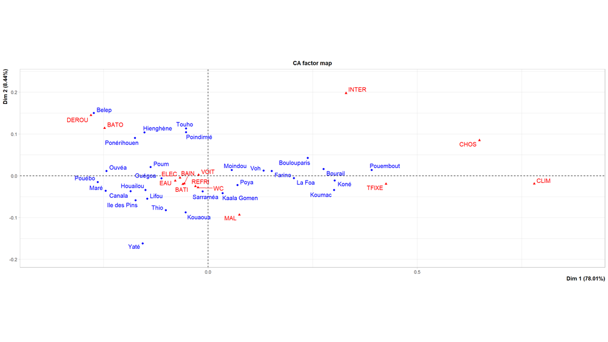

On affiche le résumé de l’analyse avec les contributions de toutes les communes et toutes les variables d’équipement.

```
##
## Call:
## CA(X = df_communes %>% select(-NEM, -NEM100, -COUNT), graph = FALSE)
##
## The chi square of independence between the two variables is equal to 12 (p-value =  1 ).
##
## Eigenvalues
##                        Dim.1   Dim.2   Dim.3   Dim.4   Dim.5   Dim.6   Dim.7   Dim.8   Dim.9  Dim.10  Dim.11  Dim.12  Dim.13
## Variance               0.038   0.004   0.002   0.001   0.001   0.001   0.000   0.000   0.000   0.000   0.000   0.000   0.000
## % of var.             78.011   8.439   4.959   2.592   1.893   1.589   0.890   0.784   0.372   0.273   0.111   0.060   0.028
## Cumulative % of var.  78.011  86.450  91.409  94.000  95.893  97.483  98.373  99.157  99.528  99.801  99.912  99.972 100.000
##
## Rows
##                Iner*1000    Dim.1    ctr   cos2    Dim.2    ctr   cos2    Dim.3    ctr   cos2
## Belep        |     3.425 | -0.273  6.284  0.694 |  0.150 17.437  0.208 |  0.076  7.667  0.054 |
## Boulouparis  |     2.686 |  0.238  5.944  0.836 |  0.042  1.739  0.026 |  0.089 12.918  0.116 |
## Bourail      |     3.200 |  0.276  8.065  0.953 |  0.016  0.257  0.003 |  0.043  3.016  0.023 |
## Canala       |     1.204 | -0.185  2.860  0.898 | -0.037  1.052  0.036 | -0.005  0.031  0.001 |
## Farino       |     1.396 |  0.152  2.497  0.676 |  0.011  0.128  0.004 |  0.006  0.059  0.001 |
## Hienghène    |     1.326 | -0.152  1.952  0.556 |  0.104  8.403  0.259 | -0.058  4.428  0.080 |
## Houailou     |     0.823 | -0.150  1.955  0.898 | -0.034  0.949  0.047 | -0.008  0.083  0.002 |
## Ile des Pins |     1.209 | -0.173  2.455  0.768 | -0.059  2.595  0.088 |  0.011  0.162  0.003 |
## Kaala Gomen  |     0.218 |  0.035  0.113  0.195 | -0.042  1.479  0.277 | -0.027  1.036  0.114 |
## Koné         |     3.845 |  0.303  9.419  0.926 | -0.011  0.124  0.001 | -0.026  1.069  0.007 |
## Koumac       |     3.809 |  0.301  9.443  0.937 | -0.034  1.114  0.012 |  0.036  2.152  0.014 |
## La Foa       |     1.774 |  0.205  4.312  0.919 | -0.006  0.032  0.001 |  0.050  3.989  0.054 |
## Lifou        |     0.942 | -0.145  1.823  0.732 | -0.055  2.421  0.105 | -0.017  0.382  0.010 |
## Maré         |     2.349 | -0.245  4.915  0.791 | -0.036  0.974  0.017 |  0.035  1.609  0.016 |
## Moindou      |     0.294 |  0.056  0.319  0.410 |  0.014  0.176  0.024 |  0.017  0.438  0.036 |
## Ouégoa       |     0.708 | -0.112  1.074  0.573 | -0.006  0.028  0.002 |  0.064  5.581  0.189 |
## Ouvéa        |     1.912 | -0.243  4.259  0.842 |  0.011  0.086  0.002 |  0.028  0.866  0.011 |
## Poindimié    |     0.686 | -0.053  0.258  0.142 |  0.104  9.321  0.556 | -0.073  7.723  0.271 |
## Ponérihouen  |     1.326 | -0.175  2.680  0.764 |  0.091  6.624  0.204 | -0.015  0.325  0.006 |
## Pouébo       |     2.466 | -0.264  6.014  0.922 | -0.015  0.186  0.003 |  0.070  6.572  0.064 |
## Pouembout    |     6.355 |  0.391 16.349  0.972 |  0.014  0.186  0.001 | -0.024  0.938  0.004 |
## Poum         |     0.984 | -0.137  1.432  0.550 |  0.021  0.301  0.013 |  0.061  4.413  0.108 |
## Poya         |     0.310 |  0.070  0.462  0.563 | -0.022  0.422  0.056 | -0.017  0.403  0.031 |
## Sarraméa     |     0.202 | -0.013  0.016  0.029 | -0.037  1.210  0.245 | -0.029  1.195  0.142 |
## Thio         |     0.608 | -0.101  0.859  0.534 | -0.083  5.324  0.358 |  0.002  0.004  0.000 |
## Touho        |     0.949 | -0.053  0.256  0.102 |  0.113 10.913  0.470 | -0.104 15.798  0.400 |
## Voh          |     0.963 |  0.133  1.691  0.664 |  0.012  0.133  0.006 | -0.076  8.778  0.219 |
## Yaté         |     1.813 | -0.156  2.044  0.426 | -0.162 20.243  0.457 | -0.038  1.919  0.025 |
## Kouaoua      |     0.676 | -0.054  0.250  0.140 | -0.088  6.145  0.372 | -0.069  6.448  0.229 |
##
## Columns
##                Iner*1000    Dim.1    ctr   cos2    Dim.2    ctr   cos2    Dim.3    ctr   cos2
## ELEC         |     0.955 | -0.067  1.253  0.496 | -0.005  0.059  0.003 |  0.019  1.578  0.040 |
## EAU          |     0.988 | -0.079  1.803  0.690 | -0.012  0.384  0.016 | -0.021  2.105  0.051 |
## BATI         |     0.703 | -0.061  1.077  0.579 | -0.020  1.088  0.063 | -0.016  1.232  0.042 |
## BAIN         |     0.539 | -0.057  0.946  0.663 | -0.019  0.939  0.071 | -0.007  0.236  0.010 |
## WC           |     0.429 | -0.024  0.166  0.146 | -0.028  2.035  0.194 | -0.008  0.260  0.015 |
## MAL          |     1.590 |  0.075  1.236  0.294 | -0.093 17.943  0.461 | -0.017  1.021  0.015 |
## REFRI        |     0.285 | -0.030  0.250  0.332 | -0.025  1.573  0.225 | -0.007  0.179  0.015 |
## CLIM         |    13.302 |  0.780 33.088  0.940 | -0.019  0.183  0.001 |  0.143 17.597  0.032 |
## CHOS         |     8.194 |  0.649 19.239  0.888 |  0.085  3.049  0.015 |  0.094  6.316  0.019 |
## TFIXE        |     6.047 |  0.425 13.837  0.865 | -0.019  0.267  0.002 |  0.037  1.658  0.007 |
## INTER        |     6.810 |  0.329 11.272  0.626 |  0.198 37.466  0.225 | -0.159 41.139  0.145 |
## VOIT         |     0.279 | -0.023  0.116  0.157 |  0.003  0.013  0.002 | -0.010  0.373  0.032 |
## BATO         |     3.965 | -0.248  7.460  0.711 |  0.114 14.632  0.151 |  0.093 16.615  0.101 |
## DEROU        |     4.371 | -0.280  8.256  0.714 |  0.145 20.369  0.191 |  0.077  9.693  0.053 |
```

### AFC de l’équipement des ménages par CSP de l’ensemble des individus actifs

On utilise la même méthode AFC mais cette fois entre équipement et catégories socio professionnelle (8 postes) de *l’ensemble des individus actifs de la BI* (pas seulement les référents de ménages). Pour cela, on joint sur la BI 2019 pour porter, les informations de logements seront *dupliquées* pour tous ses occupants actifs. On définit ici *actif* comme un individu avec une CSP autre que *retraités* (7) et *autres personnes sans activité professionnelle* (8). On commence par charge la BI 2019.

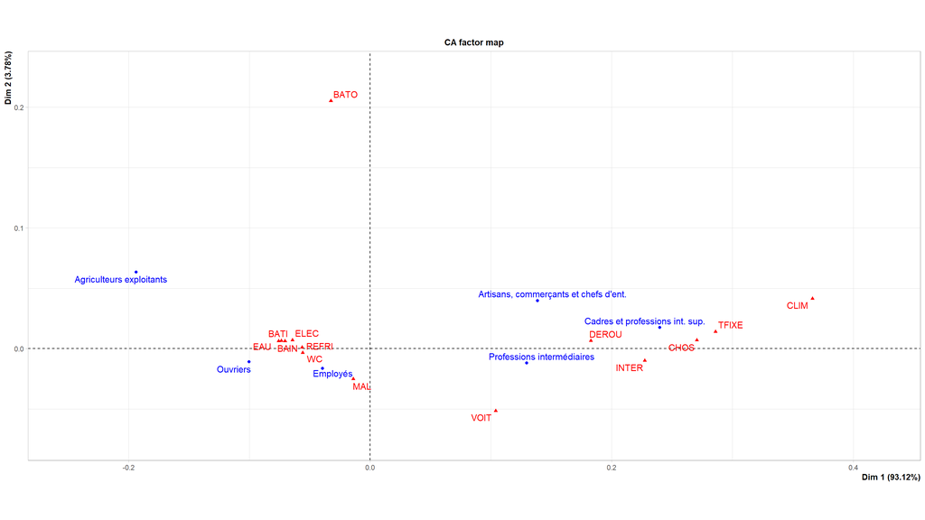

On retrouve sensiblement les mêmes groupements de variables d’équipement sur un premier axe avec 93.1% de variance et un second marqué par la mobilité avec 3.8% d’inertie.

- le groupe `CLIM`, `TFIXE`, `CHOS` et `INTER` est à proximité des CSP+, PI et artisans, qui tous les deux marquent le premier axe factoriel,
- le groupe `REFRI`, `ELEC`, `BAIN`, `MAL`, `WC` et `EAU` est proche du vers le profil moyen,
- `BATO` est un marqueur très fort des deux axes, `DEROU` aussi, `VOIT` moins.

```
##                                       ELEC  EAU BATI BAIN   WC  MAL REFRI CLIM CHOS TFIXE INTER VOIT BATO DEROU
## Agriculteurs exploitants              2433 2518 2515 2499 2298 1806  2325  289  275   427   668  782  212    37
## Artisans, commerçants et chefs d'ent. 2407 2435 2483 2505 2443 2275  2445 1052  686  1190  1497 1472  233    42
## Cadres et professions int. sup.       1556 1565 1572 1572 1553 1468  1546  829  614   875  1174 1103  118    38
## Professions intermédiaires            5205 5267 5310 5333 5247 4930  5209 1989 1444  2426  3402 3442  335   141
## Employés                              7101 7245 7258 7253 7006 6353  7025 1604 1383  2146  3034 3441  318   101
## Ouvriers                              8436 8805 8877 8867 8535 7451  8423 1516 1297  1993  3148 4371  574   113
```

### AFC de l’équipement des ménages par niveau de diplôme de l’ensemble des individus actifs

Cette fois-ci on fait l’analyse par catégorie de diplômes des individus de la BI, avec une allure assez semblable au final constitué des mêmes groupes de variables.

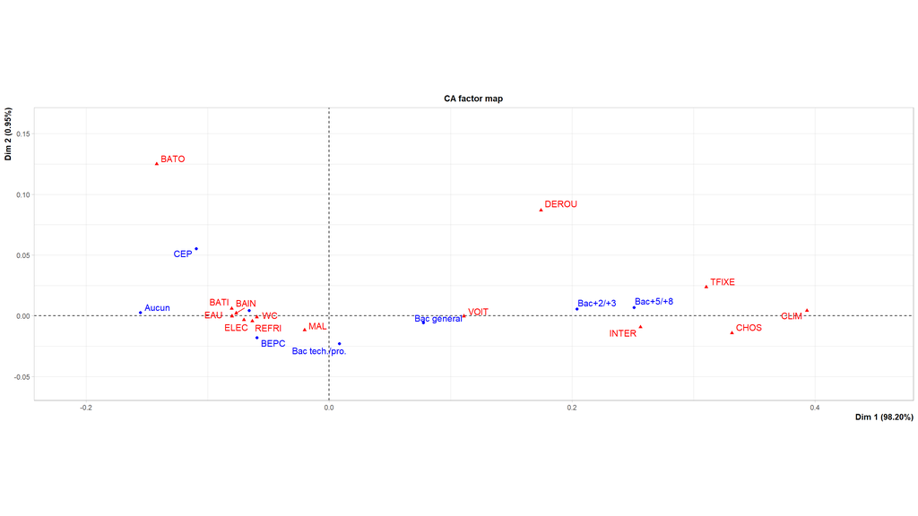

On voit que la représentation est franche, avec

- une premier axe qui capture 98.2% de la variance,
- les diplômes **sont parfaitement ordonnés selon la durée des études** sur le premier axe :
  - Aucun diplôme et CEP;
  - BEPC et CAP/BEP;
  - Bacs technologiques ou professionnel puis les bacs généraux;
  - Bac+2/+3 et Bac+5/+8
- on retrouve les groupements similaires d’équipements,
- et également un poids important de la mobilité, sauf voiture.

```
##                ELEC  EAU BATI BAIN   WC  MAL REFRI CLIM CHOS TFIXE INTER VOIT BATO DEROU
## Aucun          6218 6511 6545 6501 6152 5159  6148  876  766  1279  1966 2616  435    83
## CEP             776  801  828  820  773  670   764  133  108   221   267  360   82    14
## BEPC           2096 2140 2123 2142 2049 1852  2075  457  370   555   876  981  120    31
## CAP/BEP        7438 7620 7704 7692 7388 6550  7354 1578 1251  2012  2983 3835  538   122
## Bac général    2564 2594 2607 2619 2571 2404  2547  838  652  1079  1461 1530  148    48
## Bac tech./pro. 2969 3020 3021 3045 2970 2743  2966  800  661   977  1447 1648  158    40
## Bac+2/+3       2111 2159 2176 2188 2171 2034  2131 1031  766  1146  1541 1460  139    45
## Bac+5/+8       2966 2990 3011 3022 3008 2871  2988 1566 1125  1788  2382 2181  170    89
```

### AFC de l’équipement des ménages par ethnie de l’ensemble des individus actifs

Cette fois enfin on fait l’analyse par groupe ethnique des individus de la BI et on s’abstiendra de toute autre commentaire.

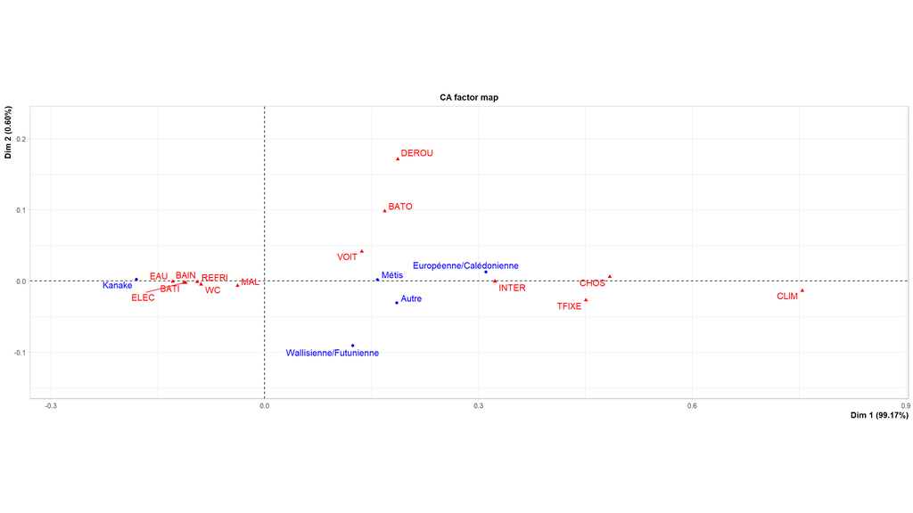

```
##
## Call:
## CA(X = df_eth_bi, graph = FALSE)
##
## The chi square of independence between the two variables is equal to 11106 (p-value =  0 ).
##
## Eigenvalues
##                        Dim.1   Dim.2   Dim.3   Dim.4
## Variance               0.046   0.000   0.000   0.000
## % of var.             99.168   0.599   0.141   0.092
## Cumulative % of var.  99.168  99.767  99.908 100.000
##
## Rows
##                           Iner*1000    Dim.1    ctr   cos2    Dim.2    ctr   cos2    Dim.3    ctr   cos2
## Autre                   |     2.956 |  0.185  6.240  0.964 | -0.031 28.604  0.027 | -0.011 14.902  0.003 |
## Européenne/Calédonienne |    21.422 |  0.311 46.804  0.998 |  0.013 13.174  0.002 |  0.007 17.324  0.001 |
## Kanake                  |    18.546 | -0.180 40.604  1.000 |  0.002  0.991  0.000 |  0.001  0.932  0.000 |
## Métis                   |     2.656 |  0.158  5.715  0.983 |  0.002  0.142  0.000 | -0.017 46.416  0.011 |
## Wallisienne/Futunienne  |     0.470 |  0.124  0.637  0.619 | -0.091 57.090  0.335 |  0.026 20.427  0.028 |
##
## Columns
##                           Iner*1000    Dim.1    ctr   cos2    Dim.2    ctr   cos2    Dim.3    ctr   cos2
## ELEC                    |     1.461 | -0.114  3.191  0.998 | -0.002  0.208  0.000 |  0.005  3.809  0.002 |
## EAU                     |     1.926 | -0.129  4.212  0.999 | -0.001  0.031  0.000 |  0.001  0.217  0.000 |
## BATI                    |     1.496 | -0.113  3.270  0.998 | -0.002  0.257  0.000 | -0.001  0.120  0.000 |
## BAIN                    |     1.442 | -0.111  3.149  0.997 | -0.002  0.236  0.000 | -0.003  1.691  0.001 |
## WC                      |     0.900 | -0.089  1.962  0.995 | -0.005  0.890  0.003 | -0.004  2.731  0.002 |
## MAL                     |     0.161 | -0.038  0.321  0.912 | -0.007  1.587  0.027 | -0.002  0.786  0.003 |
## REFRI                   |     1.005 | -0.095  2.200  1.000 | -0.001  0.062  0.000 |  0.001  0.181  0.000 |
## CLIM                    |    17.196 |  0.754 37.581  0.998 | -0.014  2.078  0.000 | -0.028 35.995  0.001 |
## CHOS                    |     5.546 |  0.484 12.118  0.998 |  0.006  0.287  0.000 |  0.018 11.814  0.001 |
## TFIXE                   |     7.666 |  0.451 16.692  0.994 | -0.027 10.069  0.004 |  0.020 23.007  0.002 |
## INTER                   |     5.598 |  0.323 12.240  0.999 | -0.001  0.005  0.000 |  0.007  3.716  0.000 |
## VOIT                    |     1.235 |  0.136  2.454  0.907 |  0.041 37.632  0.084 | -0.009  7.735  0.004 |
## BATO                    |     0.284 |  0.168  0.461  0.740 |  0.098 25.847  0.251 |  0.019  4.080  0.009 |
## DEROU                   |     0.134 |  0.187  0.149  0.508 |  0.171 20.811  0.427 |  0.037  4.117  0.020 |
```

## Distribution et évolution du NEM

### Par province

On représente les variations du NEM100 par province sur chacune des années de recensement avec une représentation *violin plot* qui permet de comparer les distributions des valeurs entre classes. On va comparer les profils sur chacun des 3 RP. On commence par fusionner tous les BL avec une nouvelle colonne d’années puis on trace un *violin plot* pour chaque province et chaque année.

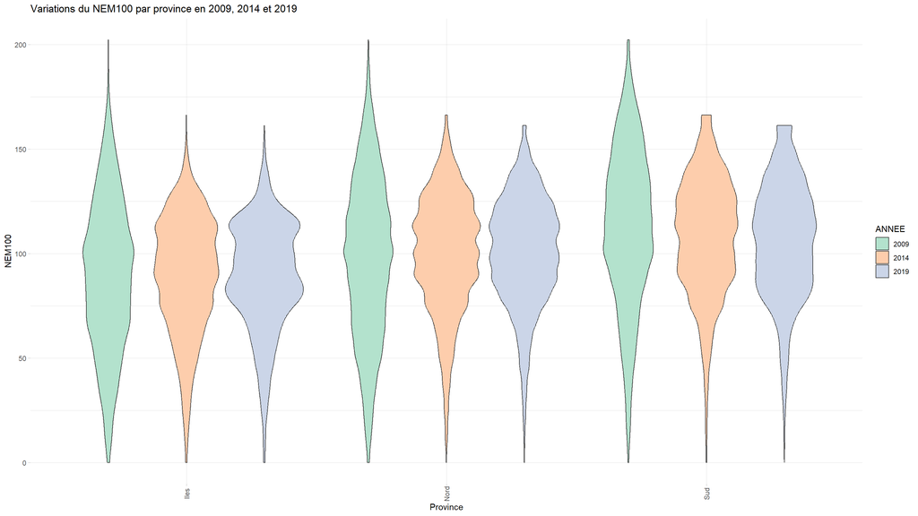

```
## # A tibble: 3 × 7
## # Groups:   PROV [3]
##   PROV  mean_2009 mean_2014 mean_2019 sd_2009 sd_2014 sd_2019
##   <chr>     <dbl>     <dbl>     <dbl>   <dbl>   <dbl>   <dbl>
## 1 Iles       89.3      89.3      88.9    35.7    28.0    25.9
## 2 Nord       97.6      99.8     101.     38.1    27.8    25.8
## 3 Sud       113.      108.      106.     37.5    28.3    27.8
```

### Par commune

On va faire la même représentation cette fois-ci sur le sous-ensemble des neuf communes d’intérêt du projet, à savoir (variable `TYPE` de `src-communes/communes.csv`) :

On commence par charger les trois BL que l’on joint avec les communes.

Ensuite, on représente l’évolution de la distribution du `NEM100` en 2009, 2014 et 2019 avec la même représentation que pour les provinces.

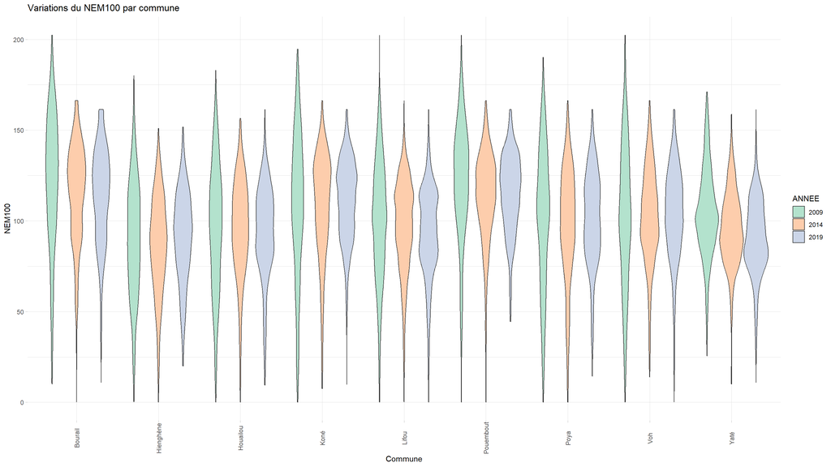

L’allure générale est encore à la réduction des inégalités, mais au niveau des communes, on constate certains variations opposées, en particulier sur Yaté. La variation entre 2009 et 2019 est calculée en % pour la moyenne du NEM100 et en valeur absolue pour l’écart type. Les valeurs numériques sont données ci-après.

```
## # A tibble: 9 × 9
## # Groups:   NOM_COMMUNE [9]
##   NOM_COMMUNE mean_2009 mean_2014 mean_2019 sd_2009 sd_2014 sd_2019 diff_pc_mean_2019_2009 diff_abs_sd_2019_2009
##   <chr>           <dbl>     <dbl>     <dbl>   <dbl>   <dbl>   <dbl>                  <dbl>                 <dbl>
## 1 Bourail         123.      115.      114.     37.1    27.5    26.6                 -6.95                 -10.5
## 2 Hienghène        90.2      86.9      91.3    31.6    26.7    24.7                  1.14                  -6.92
## 3 Houailou         96.2      95.9      94.1    34.6    26.9    25.3                 -2.21                  -9.32
## 4 Koné            109.      108.      111.     39.6    29.1    22.5                  1.95                 -17.2
## 5 Lifou            99.8      97.1      93.1    32.8    25.2    24.6                 -6.76                  -8.15
## 6 Pouembout       122.      113.      115.     32.7    24.7    21.4                 -5.16                 -11.2
## 7 Poya            102.       98.0     101.     37.9    31.0    25.5                 -1.12                 -12.3
## 8 Voh             103.      102.      104.     38.7    26.4    25.3                  0.795                -13.4
## 9 Yaté            104.       95.6      90.4    24.4    20.9    20.8                -13.5                   -3.69
```

### Infra communes sur VKPP en 2019

Enfin, on représente la distribution du NEM100 sur les IRIS de VKPP. On ajoute sur cette représentation moyenne (trait) et mediane (point).

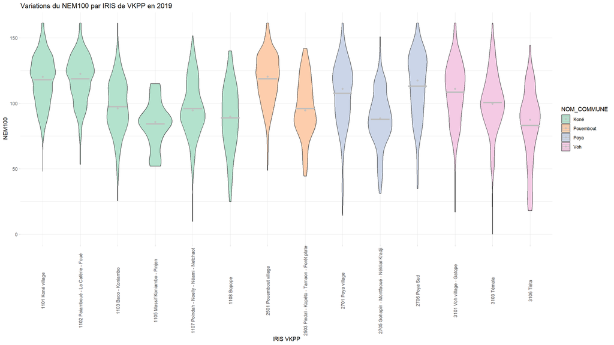

Les valeurs numériques sont données ci-après.

```
## # A tibble: 14 × 5
## # Groups:   NOM_COMMUNE, IRISUNC [14]
##    NOM_COMMUNE IRISUNC LIB_IRIS                                mean    sd
##    <chr>       <chr>   <chr>                                  <dbl> <dbl>
##  1 Koné        1101    Koné village                           118.   18.7
##  2 Koné        1102    Paiamboué - La Caférie - Foué          119.   18.1
##  3 Koné        1103    Baco - Koniambo                         97.4  20.9
##  4 Koné        1105    Massif Koniambo - Pinjen                84.3  17.7
##  5 Koné        1107    Poindah - Noelly - Néami - Netchaot     96.2  22.3
##  6 Koné        1108    Bopope                                  89.0  25.5
##  7 Pouembout   2501    Pouembout village                      119.   19.4
##  8 Pouembout   2503    Pindaï - Kopéto - Tamaon - Forêt plate  96.1  22.2
##  9 Poya        2701    Poya village                           108.   24.3
## 10 Poya        2705    Gohapin - Montfaoué - Nékliaï Kradji    87.9  21.7
## 11 Poya        2706    Poya Sud                               113.   24.9
## 12 Voh         3101    Voh village - Gatope                   109.   23.8
## 13 Voh         3103    Témala                                 101.   23.6
## 14 Voh         3106    Tiéta                                   83.1  28.0
```

On constate une **importante variation intra-communale** qui ne saurait être expliquée par la distance à la mine ou à l’usine, mais plutôt par leur homogénéité sociale.

## Représentations spatiales du NEM

On charge le shapefile des IRIS pour pouvoir générer des cartes et on joint la définition géographique au NEM via les codes des IRIS. On étoffe le jeu de données avec quelques indicateurs synthétiques par IRIS :

- `COUNT_DIFF_0919` : pourcentage relatif d’évolution 2009-2019 du nombre de logements,
- `NEM100_MEAN_PC_DIFF_0919` : pourcentage relatif d’évolution 2009-2019 de la moyenne du NEM base 100,
- `NEM100_SD_ABS_DIFF_0919` : évolution en valeur absolue 2009-2019 de *l’écart-type* du NEM base 100,
- `NEM100_SD_ABS_DIFF_0914` : idem entre 2009 et 2014,
- `NEM100_SD_ABS_DIFF_1419` : idem entre 2014 et 2019.

On rappelle qu’on ne compte *que les résidences principales* de la BL.

Globalement, il y a eu une évolution 25.002% du nombre de résidences principales en NC qui passe de 22090 en 2009 à 27613 en 2019. Pour une meilleure lisibilité, on sépare la carte du Grand Nouméa (GN) du reste du territoire.

### Nombre de logements par IRIS

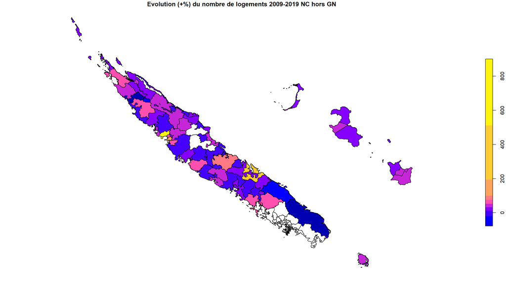

En affichant les premiers résultats, on constate une forte évolution sur Koné (commune n°11), avec aussi la présence de Canala (n°04) et Houailou (n°08) à l’est. Attention toutefois *aux effectifs qui peuvent être **très** faibles* et qui expliquent certaines augmentation très importantes. Ci-dessous, le top 20 des IRIS où le nombre de logements augmente le plus entre 2009 et 2019. Si on prend en compte les IRIS du Grand Nouméa, on voit certaines évolutions dont Nouville en particulier.

```
##                                 LIB_IRIS  NOM_COMMUNE COUNT_DIFF_0919 COUNT_09 COUNT_19
## 1105            Massif Koniambo - Pinjen         Koné           900.0        2       20
## 0404                            Mé Kwaré       Canala           511.1        9       55
## 1102       Paiamboué - La Caférie - Foué         Koné           193.4      228      669
## 0808           Kua - Néoua - Gwa Ruviano     Houailou           100.0       24       48
## 0204                        Tomo-Ouinané  Boulouparis            75.1      189      331
## 2706                            Poya Sud         Poya            73.1       52       90
## 0201                 Boulouparis village  Boulouparis            68.2      434      730
## 2501                   Pouembout village    Pouembout            65.7      487      807
## 1006       Massif Ouazangou - Mont Kaala  Kaala Gomen            63.2       19       31
## 1101                        Koné village         Koné            61.9      632     1023
## 2603            Bouarou - Pangaï - Naraï         Poum            61.4      127      205
## 1107 Poindah - Noelly - Néami - Netchaot         Koné            52.2      360      548
## 0902                      Kunié hors Vao Ile des Pins            51.7      238      361
## 0705 Oué - Hawa - Ouen - Kout - Pwa Jilu    Hienghène            50.0       16       24
## 1401                             Gaïtcha        Lifou            48.1      341      505
## 0304                       Nandaï Boghen      Bourail            46.2      355      519
## 3101                Voh village - Gatope          Voh            45.6      364      530
## 1108                              Bopope         Koné            45.2       42       61
## 0302                       Poé Nessadiou      Bourail            42.2      332      472
## 1502                            La Roche         Maré            40.8      191      269
```

### Evolution du NEM moyen par IRIS

On va maintenant s’intéresser à l’évolution de la moyenne du NEM base 100 par IRIS entre 2009 et 2019, ici on colorie selon 10 déciles du NEM100.

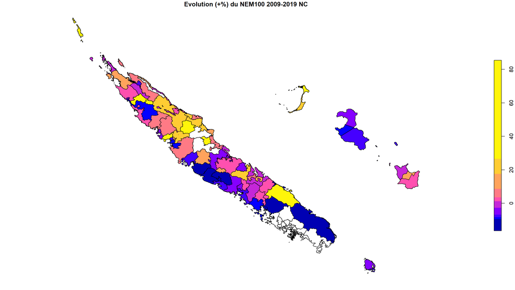

```
##      NOM_COMMUNE                                         LIB_IRIS NEM100_MEAN_PC_DIFF_0919 NEM100_MEAN_09 NEM100_MEAN_19
## 1108        Koné                                           Bopope                     85.4           48.0           89.0
## 2906        Thio                                          Borendy                     53.8           54.4           83.7
## 0101       Belep                                            Bélep                     47.6           61.4           90.6
## 1206      Koumac                                  Piton de Pandop                     46.2           68.4          100.0
## 1105        Koné                         Massif Koniambo - Pinjen                     42.2           59.3           84.3
## 2303 Ponérihouen               Goyetta - Goa - Nébouéba - St Yves                     41.5           64.7           91.5
## 1004 Kaala Gomen                       Ouéholle - Ouémou - Kourou                     32.8           67.1           89.1
## 2001       Ouvéa                    Saint Joseph Gossanah Takedji                     32.2           54.8           72.5
## 0705   Hienghène              Oué - Hawa - Ouen - Kout - Pwa Jilu                     26.0           58.3           73.5
## 2202   Poindimié                                      Tiéti - Tyé                     24.9           75.0           93.6
## 1107        Koné              Poindah - Noelly - Néami - Netchaot                     24.5           77.2           96.2
## 3003       Touho           Tiouandé - Ouanache - Congouma - Paola                     23.3           79.6           98.2
## 3302     Kouaoua                        Méa Mébara - Ouérou Pimet                     23.2           73.4           90.4
## 2003       Ouvéa                                            Mouli                     19.2           56.9           67.8
## 3004       Touho                Koe - Kokingone - Tiwaka - Pombéi                     18.9           74.3           88.4
## 2002       Ouvéa                                          Fayaoué                     18.5           71.1           84.3
## 2204   Poindimié Tibarama - Bayes - Ouindo - Ometteux - Napoémien                     17.4           81.8           96.0
## 1502        Maré                                         La Roche                     14.5           74.2           85.0
## 0305     Bourail                                               Ny                     14.2           82.0           93.6
## 0403      Canala                    Gélima - Kuiné - Mia - Nakéty                     13.0           76.5           86.4
```

On constate, *avec cette échelle de couleur basée sur 10 quintiles*, une assez franche séparation Nord/Est versus Sud/Ouest

### Evolution de l’écart-type du NEM par IRIS

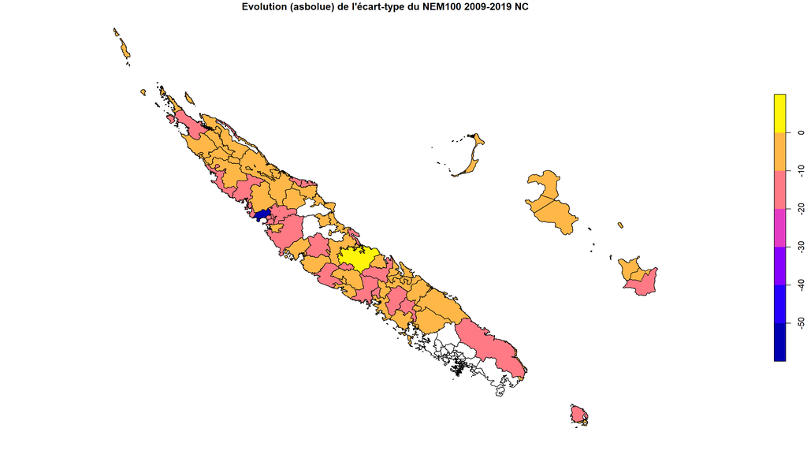

L’écart type du NEM100 **a été considérable réduit sur l’ensemble du territoire**, sauf sur les IRIS ci-dessous. On rappelle que écart-type NC du NEM100 passe de 30.6 en 2009 à 24.2 en 2014 puis 23.5 en 2019, soit un différence de -7.08 points entre 2009 et 2019.

```
##      NOM_COMMUNE                  LIB_IRIS COUNT_19 NEM100_SD_ABS_DIFF_0919 NEM100_SD_09 NEM100_SD_19
## 0808    Houailou Kua - Néoua - Gwa Ruviano       48                    4.54         23.8         28.4
```

En comparaison, on garde ici les variations les plus importantes.

```
##      NOM_COMMUNE                               LIB_IRIS COUNT_19 NEM100_SD_ABS_DIFF_0919 NEM100_SD_09 NEM100_SD_19
## 1105        Koné               Massif Koniambo - Pinjen       20                   -55.0         72.8        17.74
## 3001       Touho                          Touho village      339                   -14.3         35.4        21.09
## 0303     Bourail                    Domaine Deva Le Cap       42                   -14.1         35.7        21.58
## 3103         Voh                                 Témala      282                   -14.0         37.6        23.55
## 1001 Kaala Gomen                    Kaala Gomen village      452                   -14.0         37.7        23.73
## 3203        Yaté         Ouinné Pourina Plaine des lacs        2                   -13.9         23.8         9.87
## 0305     Bourail                                     Ny      267                   -13.9         34.0        20.12
## 3101         Voh                   Voh village - Gatope      530                   -12.9         36.7        23.78
## 2603        Poum               Bouarou - Pangaï - Naraï      205                   -12.5         41.7        29.22
## 2503   Pouembout Pindaï - Kopéto - Tamaon - Forêt plate      146                   -12.3         34.5        22.23
```

On proccède similairement pour la différence d’écrt type par IRIS entre 2009 et 2014.

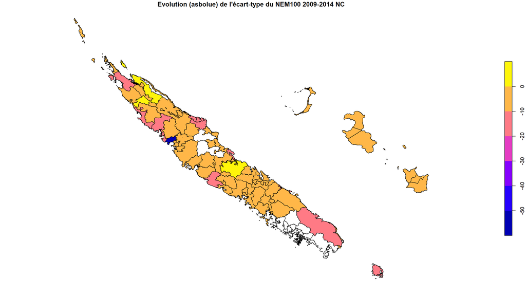

On retrouve les IRIS où l’écart progresse :

```
##      NOM_COMMUNE                  LIB_IRIS COUNT_14 NEM100_SD_ABS_DIFF_0914 NEM100_SD_09 NEM100_SD_14
## 0808    Houailou Kua - Néoua - Gwa Ruviano       76                   7.590         23.8         31.4
## 1206      Koumac           Piton de Pandop        3                   0.894         28.5         29.4
## 1902      Ouégoa               Pam - Tiari       67                   0.595         29.2         29.7
```

Et de même entre 2014 et 2019. Ici, des écart substantiels apparaissent sur beaucoup plus de communes, **attention au changement des classes de couleurs**.

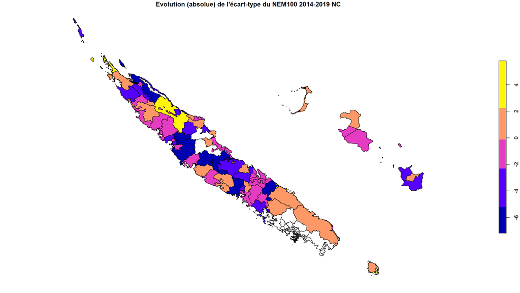

On appréciera mieux avec la liste :

```
##       NOM_COMMUNE                                         LIB_IRIS COUNT_14 NEM100_SD_ABS_DIFF_1419 NEM100_SD_14 NEM100_SD_19
## 2601         Poum                             Poum village - Titch      230                   5.796        27.48        33.27
## 2901         Thio                                     Thio village      473                   3.654        22.37        26.03
## 0901 Ile des Pins                                              Vao      252                   3.417        21.04        24.46
## 0705    Hienghène              Oué - Hawa - Ouen - Kout - Pwa Jilu       18                   3.281        19.34        22.62
## 2001        Ouvéa                    Saint Joseph Gossanah Takedji      230                   2.247        26.52        28.77
## 3004        Touho                Koe - Kokingone - Tiwaka - Pombéi      148                   2.115        20.87        22.98
## 1006  Kaala Gomen                    Massif Ouazangou - Mont Kaala       20                   2.097        28.39        30.48
## 2906         Thio                                          Borendy       71                   1.832        21.07        22.90
## 1004  Kaala Gomen                       Ouéholle - Ouémou - Kourou       80                   1.430        22.95        24.38
## 3203         Yaté                   Ouinné Pourina Plaine des lacs       10                   1.256         8.62         9.87
## 1202       Koumac                             Pagou - Paop - Wanac      211                   1.181        22.49        23.67
## 0301      Bourail                                  Bourail village      621                   0.991        24.74        25.73
## 3003        Touho           Tiouandé - Ouanache - Congouma - Paola      143                   0.971        22.03        23.00
## 2801     Sarraméa                                         Sarraméa      184                   0.927        23.39        24.32
```

[output cut: 16 more lines]

## Influence de la mine

Dans cette partie, nous allons comparer les contributions de différents co-facteurs au NEM100 et en particulier l’influence du facteur de durée de trajet à la mine.

### Variable `MINE`

La BI 2019 contient une variable `MINE` *l’individu travaille en lien avec la mine*. Cette variable était aussi présente dans le BI 2014 de P. Rivoilant mais pas sur la version à disposition à l’ISEE. La variable `MINE` concerne 6162 actifs qui sont **tous** actifs dans le secteur *B - Industries extractives* (variable `SECT21`). Seuls 68 actifs de ce secteur en sont exclus, a priori, ils concernent le secteur carrière (caillasse, sables, schistes, etc.) *hors nickel* comme la carrière de Dumbéa.

```
##      A    B    C   D   E    F     G    H    I    J    K   L    M    N     O     P    Q   R    S    T   U
## 0 5758   68 5837 665 564 9984 13625 5343 5076 2629 2203 731 4969 7800 14873 10209 8971 855 2078 2854 213
## 1   NA 6162   NA  NA  NA   NA    NA   NA   NA   NA   NA  NA   NA   NA    NA    NA   NA  NA   NA   NA  NA
```

La variable `MINE` est inégalement répartie entre les ethnies, comme le montre le test du chi carré suivant où on donne sucessivement :

1. le tableau des effectifs,
2. le tableau des résidus,
3. le tableau des contributions, en % des résidus.

On constante :

- la sur-représentation des Kanaks (56.8 % de contribution au score),
- la sous-représentation des Européen/Calédoniens (31.0 % de contribution),
- peu de différence pour les autres ethnies.

```
##   Autre Européenne/Calédonienne Kanake Métis Wallisienne/Futunienne
## 0 14792                   36751  34404 10647                   8711
## 1   628                    1164   3346   643                    381
```

```
##   Autre Européenne/Calédonienne Kanake  Métis Wallisienne/Futunienne
## 0  1.86                    4.92  -6.67 -0.183                   1.31
## 1 -7.69                  -20.36  27.56  0.756                  -5.42
```

```
##   Autre Européenne/Calédonienne Kanake  Métis Wallisienne/Futunienne
## 0 0.259                    1.81   3.32 0.0025                  0.129
## 1 4.419                   30.99  56.82 0.0427                  2.201
```

Sur l’ensemble de la NC, le % d’actifs dans la mine est de 5.528. On calcule le % d’actifs dans le secteur nickel identifiés par la variable `MINE` de chaque commune que

```
## # A tibble: 33 × 5
##    NOM_COMMUNE  TYPE          POP_ACTIVE MINE_NB MINE_PC
##    <chr>        <chr>              <int>   <int>   <dbl>
##  1 Kouaoua      <NA>                 474     184  38.8
##  2 Kaala Gomen  <NA>                 614     203  33.1
##  3 Yaté         minier               565     173  30.6
##  4 Canala       <NA>                1088     333  30.6
##  5 Thio         <NA>                 896     245  27.3
##  6 Poya         métallurgique       1015     254  25.0
##  7 Houailou     minier              1157     238  20.6
##  8 Poum         <NA>                 532     109  20.5
##  9 Voh          métallurgique       1133     228  20.1
## 10 Koné         métallurgique       3464     567  16.4
## 11 Koumac       <NA>                1817     287  15.8
## 12 Pouembout    métallurgique       1294     184  14.2
```

[output cut: 21 more lines]

Ensuite, on représente spatialement les IRIS avec leur % d’actif dans le secteur nickel.

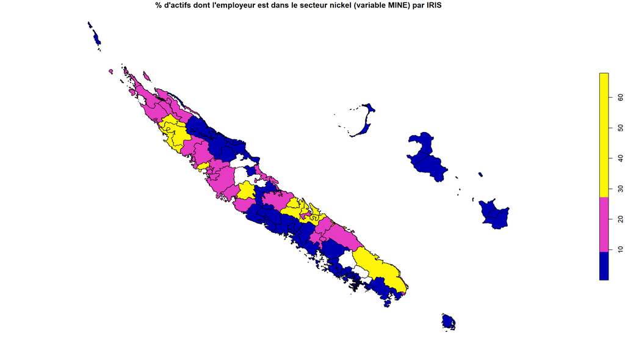

### Durée de trajet à la mine

Pour utiliser *la durée de trajet à la mine en minutes* on charge *la matrice de desserte*. Cette matrice fait correspondre à chaque IRIS la durée *médiane* (sur les noeuds routiers contenus dans l’IRIS) pour attendre le site minier (mine ou usine) *le plus proche* par la route, en roulant partour à la vitesse maximale autorisée. Notons que la transformation des données est fait essentiellement en SQL, voir le fichier `src-desserte/desserte.sql` et que le calcul de la matrice elle même a été réalisé antérieurement.

On remarque que les IRIS de la province des îles, de l’île des Pins et de Belep disparaissent, car il n’y pas de routes vers les sites miniees, il reste ainsi 158 IRIS. Comme précédement, on supprimera les communes du GN de l’étude.

On donne un exemple de la structure de la table de desserte avec 20 IRIS pris au hasard.

```
##                                  lib_iris duree_usine duree_centre duree_min
## 2107                       Tontouta Tiaré          35           31        31
## 2108                             Mont Mou          22           40        22
## 0803                                Waraï         127           19        19
## 1829                                 PK 4           4           39         4
## 0201                  Boulouparis village          57           33        33
## 1806               Motor Pool - Receiving           7           47         7
## 0506                         Jacarandas I           9           41         9
## 2705 Gohapin - Montfaoué - Nékliaï Kradji          77           35        35
## 2306               Aoupinié - Goro Darawé         104           57        57
## 0303                  Domaine Deva Le Cap          80           35        35
## 1004           Ouéholle - Ouémou - Kourou          73           40        40
## 0501                Coeur de ville urbain           7           39         7
## 3004    Koe - Kokingone - Tiwaka - Pombéi          64           75        64
## 1835                                 Tina           9           37         9
## 1711                        La Coulée Sud          23           25        23
## 2706                             Poya Sud          69           22        22
## 0508                              Auteuil           9           40         9
## 2603             Bouarou - Pangaï - Naraï          87           17        17
## 2801                             Sarraméa          86           43        43
## 2701                         Poya village          54           35        35
```

#### Durée de trajet à l’usine

On represente la cartes des durée de trajet à l’usine métallurgique des IRIS.

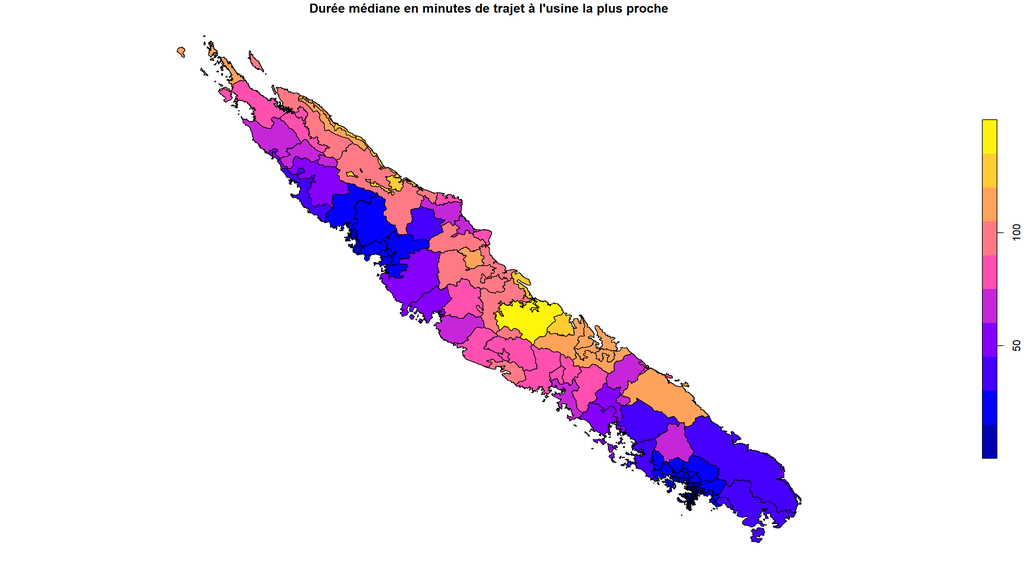

On donne la liste des IRIS par durée décroissante d’accès à l’usine, pour les IRIS à plus d’une heure de trajet. Le centre de la grande terre sur les deux côtés et le nord de la côte est sont les plus éloignés des usines.

```
##                                              LIB_IRIS COMM NOM_COMMUNE          TYPE COUNT_19 duree_usine
## 0808                        Kua - Néoua - Gwa Ruviano   08    Houailou        minier       48         139
## 0801                                 Houaïlou village   08    Houailou        minier      438         131
## 0704                         Tiendanite à Ouayaguette   07   Hienghène        témoin      210         129
## 0803                                            Waraï   08    Houailou        minier      322         127
## 2402                   Tchamboëne - Diahoué - Colnett   24      Pouébo          <NA>      234         125
## 0701                                Hienghène village   07   Hienghène        témoin      445         121
## 3301                   Kouaoua village - Amon Kasiori   33     Kouaoua          <NA>      213         121
## 0404                                         Mé Kwaré   04      Canala          <NA>       55         120
## 0805                            Nédivin - Bas Nindien   08    Houailou        minier      317         118
## 0401                                   Canala village   04      Canala          <NA>      511         114
## 0403                    Gélima - Kuiné - Mia - Nakéty   04      Canala          <NA>      496         114
## 3302                        Méa Mébara - Ouérou Pimet   33     Kouaoua          <NA>      192         114
## 2906                                          Borendy   29        Thio          <NA>       76         113
## 2405                   Massif du Panié - Mont Colnett   24      Pouébo          <NA>       NA         112
```

[output cut: 38 more lines]

#### Durée de trajet à un centre minier

On fait la même chose pour la durée d’accès à un centre minier, *id est* un site d’extraction minière. On voit que **les communes les plus éloignées sont celles de la côte est de la province Nord** comme Hienghène, Touho, Pouébo ou Poindimié.

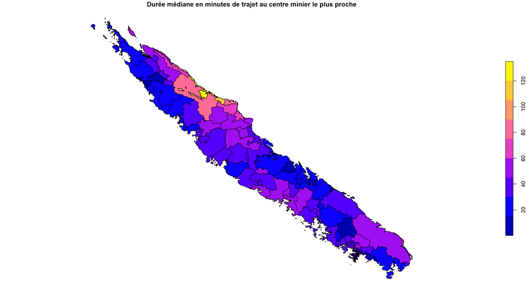

```
##                                      LIB_IRIS COMM NOM_COMMUNE          TYPE COUNT_19 duree_centre
## 0701                        Hienghène village   07   Hienghène        témoin      445          121
## 3003   Tiouandé - Ouanache - Congouma - Paola   30       Touho          <NA>      199          106
## 0704                 Tiendanite à Ouayaguette   07   Hienghène        témoin      210           98
## 3001                            Touho village   30       Touho          <NA>      339           89
## 0705      Oué - Hawa - Ouen - Kout - Pwa Jilu   07   Hienghène        témoin       24           85
## 2402           Tchamboëne - Diahoué - Colnett   24      Pouébo          <NA>      234           79
## 3004        Koe - Kokingone - Tiwaka - Pombéi   30       Touho          <NA>      186           75
## 2202                              Tiéti - Tyé   22   Poindimié          <NA>      581           68
## 2405           Massif du Panié - Mont Colnett   24      Pouébo          <NA>       NA           66
## 3202                                     Unia   32        Yaté        minier      177           64
## 1108                                   Bopope   11        Koné métallurgique       61           60
## 2401 Pouébo village - St Ferdinand - St Louis   24      Pouébo          <NA>      361           60
```

#### Durée de trajet centre comme usine.

Enfin, on dessine la carte des durées de trajet vers les centres miniers **ou** les usines métallurgiques. On remarque que le maillage des centre miniers est suffisament dense pour masquer celui des usines : la carte est sensiblement la même que la précédente.

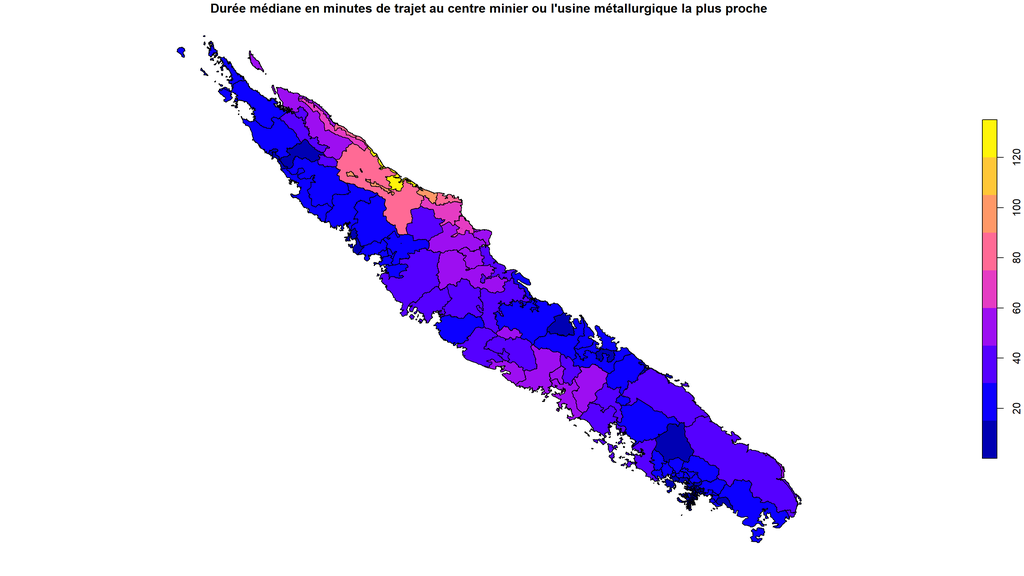

### Préparation des données

On souhaite évaluer l’influence de la distance à la mine et la comparer à différent co-facteurs sur le NEM base 100. Les co-facteurs d’intérêt sont mis sous forme catégorielle. L’analyse va porter ici sur la BI 2019 jointe à la BL via l’identifiant de logement `IDLOG`. On note qu’il y a 29871 actifs hors du GN dans la BI 2019.

```
##  [1] [045,060[ [045,060[ [045,060[ [045,060[ [045,060[ [045,060[ [045,060[ [045,060[ [045,060[ [045,060[ [045,060[ [045,060[ [045,060[ [045,060[
## [15] [045,060[ [045,060[ [045,060[ [045,060[ [045,060[ [045,060[ [045,060[ [045,060[ [045,060[ [045,060[ [045,060[ [045,060[ [045,060[ [045,060[
## [29] [045,060[ [045,060[ [045,060[ [045,060[
## Levels: [000,015[ [015,030[ [030,045[ [045,060[ [060,075[ [075,090[ [090,105[ [105,120[ [120,135[ [135,150[
```

Après jointure avec les IRIS de desserte, on obtient 23579 individus étudiés, répartis par commune comme suit. On note que les îles hors de la Grande Terre ainsi que les communes du Grand Nouméa sont exclues (`NA`).

```
## # A tibble: 33 × 4
##    NOM_COMMUNE  non_minier minier    pc
##    <chr>             <int>  <int> <dbl>
##  1 Belep                NA     NA NA
##  2 Boulouparis        1151     90  7.25
##  3 Bourail            2108     31  1.45
##  4 Canala              750    333 30.7
##  5 Dumbéa               NA     NA NA
##  6 Farino              264     11  4
##  7 Hienghène           604     16  2.58
##  8 Houailou            907    238 20.8
##  9 Ile des Pins         NA     NA NA
## 10 Kaala Gomen         411    203 33.1
## 11 Koné               2741    566 17.1
## 12 Koumac             1331    287 17.7
```

[output cut: 21 more lines]

### Durée de trajet et décile du NEM

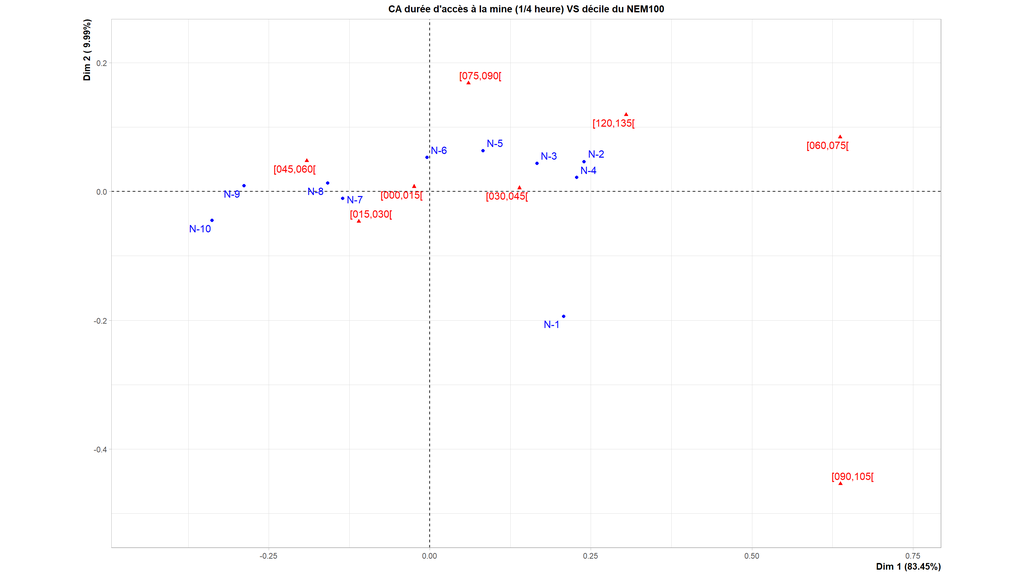

```
##
## Call:
## CA(X = df_nem_bl19_desserte, graph = FALSE)
##
## The chi square of independence between the two variables is equal to 1209 (p-value =  1.72e-211 ).
##
## Eigenvalues
##                        Dim.1   Dim.2   Dim.3   Dim.4   Dim.5   Dim.6   Dim.7
## Variance               0.043   0.005   0.001   0.001   0.001   0.000   0.000
## % of var.             83.446   9.989   2.390   2.068   1.250   0.727   0.130
## Cumulative % of var.  83.446  93.436  95.826  97.894  99.144  99.870 100.000
##
## Rows
##             Iner*1000    Dim.1    ctr   cos2    Dim.2    ctr   cos2    Dim.3    ctr   cos2
## N-1       |     8.109 |  0.208 10.112  0.533 | -0.194 73.315  0.463 |  0.002  0.022  0.000 |
## N-10      |    11.846 | -0.338 26.706  0.964 | -0.045  3.925  0.017 | -0.003  0.060  0.000 |
## N-2       |     6.429 |  0.239 13.404  0.892 |  0.046  4.204  0.033 | -0.054 24.177  0.046 |
## N-3       |     3.106 |  0.166  6.461  0.890 |  0.044  3.701  0.061 | -0.018  2.738  0.011 |
## N-4       |     5.697 |  0.228 12.140  0.911 |  0.022  0.918  0.008 |  0.014  1.569  0.003 |
## N-5       |     1.701 |  0.083  1.594  0.401 |  0.063  7.811  0.235 |  0.073 43.688  0.315 |
## N-6       |     0.823 | -0.004  0.004  0.002 |  0.053  5.417  0.337 | -0.018  2.628  0.039 |
## N-7       |     2.052 | -0.135  4.290  0.894 | -0.011  0.227  0.006 |  0.029  7.096  0.042 |
## N-8       |     2.919 | -0.158  5.861  0.859 |  0.013  0.329  0.006 |  0.018  2.778  0.012 |
## N-9       |     8.576 | -0.288 19.429  0.969 |  0.009  0.154  0.001 | -0.043 15.243  0.022 |
##
## Columns
##             Iner*1000    Dim.1    ctr   cos2    Dim.2    ctr   cos2    Dim.3    ctr   cos2
## [000,015[ |     0.948 | -0.025  0.212  0.096 |  0.008  0.168  0.009 | -0.072 61.859  0.800 |
## [015,030[ |     5.065 | -0.110  9.689  0.818 | -0.047 14.343  0.145 |  0.021 12.343  0.030 |
## [030,045[ |     4.621 |  0.139  9.822  0.909 |  0.006  0.130  0.001 |  0.000  0.000  0.000 |
## [045,060[ |     7.641 | -0.191 16.212  0.908 |  0.048  8.441  0.057 |  0.007  0.721  0.001 |
## [060,075[ |    20.967 |  0.637 47.507  0.969 |  0.085  6.993  0.017 |  0.007  0.199  0.000 |
## [075,090[ |     1.378 |  0.060  0.191  0.059 |  0.168 12.596  0.468 | -0.015  0.406  0.004 |
## [090,105[ |     8.108 |  0.638 12.332  0.651 | -0.454 52.183  0.330 | -0.017  0.305  0.000 |
## [120,135[ |     2.530 |  0.305  4.035  0.682 |  0.119  5.146  0.104 |  0.126 24.167  0.117 |
```

### Durée de trajet et variable `MINE`

Comme précédement sur l’analyse du lien entre ethnie et `MINE`, on va fait un test statistique sur la durée de trajet en groupe de 15’. On donne sucessivement :

- les effectifs observés,
- les résidus,
- les contributions (en % des résidus).

```
##            [000,015[ [015,030[ [030,045[ [045,060[ [060,075[ [075,090[ [090,105[ [120,135[
## non_minier      2558      6469      4448      4381      1033       506       290       430
## minier           936      1535       690        99       149        31        16         8
##            [000,015[ [015,030[ [030,045[ [045,060[ [060,075[ [075,090[ [090,105[ [120,135[
## non_minier     -7.74     -4.35     0.979      9.04     0.776      2.24      1.79      2.91
## minier         18.66     10.47    -2.360    -21.80    -1.870     -5.39     -4.32     -7.02
##            [000,015[ [015,030[ [030,045[ [045,060[ [060,075[ [075,090[ [090,105[ [120,135[
## non_minier      4.92      1.55    0.0787      6.72    0.0495     0.411     0.264     0.698
## minier         28.58      9.01    0.4571     39.01    0.2873     2.387     1.531     4.051
```

```
##
##  Pearson's Chi-squared test
##
## data:  df
## X-squared = 1218, df = 7, p-value <2e-16
```

On note bien une dépendance statistique entre `MINE_` et `DUREE_QUART`. Elle apparait **difficile** à interpréter, mais suggère une **intéressante absence de linéarité** entre la distance à la mine et la variable `MINE` :

- les actifs de la mine sont **sur-représentés** à moins de 30’ de trajets,
- puis chutent **brutalement** entre 45’ et 60’,
- ensuite actifs de la mine sont de mmoins en moins représentés avec la distance.

On va analyser cet *anneau* de durée de trajet entre 30 et 60 minutes, par ethnie, CSP et diplome.

```
##                         [000,015[ [015,030[ [030,045[ [045,060[ [060,075[ [075,090[ [090,105[ [120,135[
## Kanake                       2026      4495      3055      1773      1091       350       296       389
## Autre                         301       749       502       400        31        31         1        10
## Européenne/Calédonienne       622      1682      1028      1539        21        86         1        27
## Métis                         472       956       454       586        34        69         8        11
## Wallisienne/Futunienne         73       122        99       182         5         1         0         1
##                         [000,015[ [015,030[ [030,045[ [045,060[ [060,075[ [075,090[ [090,105[ [120,135[
## Kanake                     0.6543     -1.17     2.191   -15.559     15.99      2.46      9.16      8.77
## Autre                      0.0537      2.35     2.892     0.778     -7.00     -2.23     -4.93     -4.50
## Européenne/Calédonienne   -4.3987     -0.42    -1.903    19.061    -14.52     -2.62     -7.94     -6.84
## Métis                      4.5025      2.59    -4.646     4.233     -8.41      1.30     -4.42     -5.35
## Wallisienne/Futunienne     0.1688     -3.28    -0.609     9.419     -3.90     -3.02     -2.50     -2.66
##                         [000,015[ [015,030[ [030,045[ [045,060[ [060,075[ [075,090[ [090,105[ [120,135[
## Kanake                   0.023490   0.07515    0.2634   13.2818    14.023    0.3323     4.603     4.216
## Autre                    0.000158   0.30293    0.4588    0.0332     2.687    0.2719     1.334     1.112
## Européenne/Calédonienne  1.061607   0.00967    0.1986   19.9355    11.561    0.3776     3.456     2.569
## Métis                    1.112311   0.36822    1.1844    0.9831     3.881    0.0933     1.071     1.571
## Wallisienne/Futunienne   0.001563   0.58910    0.0204    4.8677     0.836    0.4988     0.344     0.389
```

```
##
##  Pearson's Chi-squared test
##
## data:  df
## X-squared = 1823, df = 28, p-value <2e-16
```

On constate une sur-représentation des Européens/Calédoniens et une sous-représentation des Kanaks dans l’anneau `[45-60[`.

```
##                                       [000,015[ [015,030[ [030,045[ [045,060[ [060,075[ [075,090[ [090,105[ [120,135[
## Agriculteurs exploitants                    165       709       460       333       160        63        65        66
## Artisans, commerçants et chefs d'ent.       305       633       498       495        49        43        25        29
## Cadres et professions int. sup.             155       627       193       238        34        27         6        22
## Professions intermédiaires                  666      1657       754       919       175       122        33        70
## Employés                                    794      1711      1314      1282       297       116        85       142
## Ouvriers                                   1409      2667      1919      1213       467       166        92       109
##                                       [000,015[ [015,030[ [030,045[ [045,060[ [060,075[ [075,090[ [090,105[ [120,135[
## Agriculteurs exploitants                 -7.771     0.877     0.935    -2.602     5.831     2.502     7.571     4.645
## Artisans, commerçants et chefs d'ent.    -0.158    -2.713     2.135     5.053    -5.402    -0.626    -0.376    -1.543
## Cadres et professions int. sup.          -2.731     8.801    -5.386    -0.596    -3.870    -0.487    -2.651    -0.444
## Professions intermédiaires                0.572     4.265    -6.588     2.898    -3.056     2.187    -3.184    -1.290
## Employés                                 -1.945    -5.387     1.781     5.790     0.543    -1.290     1.216     3.424
## Ouvriers                                  6.295    -1.204     3.980    -8.058     3.181    -1.267    -1.210    -3.304
##                                       [000,015[ [015,030[ [030,045[ [045,060[ [060,075[ [075,090[ [090,105[ [120,135[
## Agriculteurs exploitants                8.37427     0.107     0.121    0.9390    4.7148    0.8680    7.9486    2.9917
## Artisans, commerçants et chefs d'ent.   0.00347     1.021     0.632    3.5403    4.0465    0.0543    0.0197    0.3300
## Cadres et professions int. sup.         1.03433    10.742     4.022    0.0493    2.0774    0.0329    0.9746    0.0274
## Professions intermédiaires              0.04531     2.523     6.020    1.1649    1.2953    0.6633    1.4060    0.2309
## Employés                                0.52439     4.024     0.440    4.6484    0.0409    0.2307    0.2050    1.6256
## Ouvriers                                5.49578     0.201     2.197    9.0044    1.4029    0.2228    0.2032    1.5142
```

```
##
##  Pearson's Chi-squared test
##
## data:  df
## X-squared = 721, df = 35, p-value <2e-16
```

On constate une sur-représentation des cadre dans l’anneau `[15-30[`.

```
##                [000,015[ [015,030[ [030,045[ [045,060[ [060,075[ [075,090[ [090,105[ [120,135[
## Aucun                786      1830      1423       947       344       110       116       140
## CEP                   90       187       132       111        46        16        11        20
## BEPC                 311       554       332       291        91        34        14        27
## CAP/BEP             1032      2080      1511      1117       390       150       105       104
## Bac général          302       700       459       474        87        48        15        35
## Bac tech./pro.       420       827       554       521       127        73        29        45
## Bac+2/+3             275       751       369       401        51        32         6        31
## Bac+5/+8             278      1075       358       618        46        74        10        36
##                [000,015[ [015,030[ [030,045[ [045,060[ [060,075[ [075,090[ [090,105[ [120,135[
## Aucun            -1.9981    -2.355     5.161    -4.111     3.460   -1.7317     4.894     3.324
## CEP              -0.0877    -1.462    -0.136    -0.507     2.755    0.5458     1.079     2.552
## BEPC              4.2098    -0.315    -1.497    -1.312     0.888   -0.5978    -1.611    -0.672
## CAP/BEP           2.2717    -2.615     2.580    -3.301     3.588    0.1823     2.265    -1.506
## Bac général      -0.6854    -0.732    -0.138     3.548    -1.870   -0.0406    -2.386    -0.698
## Bac tech./pro.    1.8007    -1.827    -0.491     1.250    -0.275    1.8048    -0.808    -0.464
## Bac+2/+3         -0.5293     3.945    -2.374     1.937    -4.597   -1.7615    -3.783    -0.770
## Bac+5/+8         -4.7699     7.837    -7.963     6.612    -7.070    2.2788    -3.933    -1.520
##                [000,015[ [015,030[ [030,045[ [045,060[ [060,075[ [075,090[ [090,105[ [120,135[
## Aucun            0.71119    0.9876   4.74419    3.0105    2.1324  0.534224     4.267    1.9683
## CEP              0.00137    0.3806   0.00331    0.0458    1.3519  0.053063     0.208    1.1606
## BEPC             3.15708    0.0176   0.39911    0.3067    0.1405  0.063663     0.462    0.0804
## CAP/BEP          0.91932    1.2180   1.18564    1.9412    2.2933  0.005921     0.914    0.4042
## Bac général      0.08368    0.0955   0.00338    2.2421    0.6227  0.000293     1.014    0.0868
## Bac tech./pro.   0.57764    0.5944   0.04299    0.2783    0.0135  0.580274     0.116    0.0384
## Bac+2/+3         0.04990    2.7723   1.00398    0.6685    3.7638  0.552752     2.550    0.1055
## Bac+5/+8         4.05314   10.9401  11.29635    7.7871    8.9056  0.925076     2.755    0.4115
```

```
##
##  Pearson's Chi-squared test
##
## data:  df
## X-squared = 561, df = 49, p-value <2e-16
```

## Modèles pour le NEM

Dans cette dernière partie on va *fit* différent modèles au NEM base 100 pour comparer les facteurs d’analyse et d’isoler l’influence de la distance à la mine entre les facteurs. Les facteurs d’intérêts pour cette analyse sont les suivants

```
## [1] "DIPLR_ : 8 valeurs"
## [1] "AGER_ : 7 valeurs"
## [1] "CS8_ : 6 valeurs"
## [1] "MINE_ : 2 valeurs"
## [1] "ETH : 5 valeurs"
```

```
## [1] "Total : 23 degrés de liberté"
```

```
## [1] "DUREE_USINE_QUART : 10 valeurs"
## [1] "DUREE_CENTRE_QUART : 9 valeurs"
## [1] "DUREE_QUART : 8 valeurs"
```

Pour chaque modèle considéré, on calculera les indicateurs suivants entre le modèle null et celui proposé, où :

- `dev` est la différence de variation,
- `dof` est la différence du nombre de degrés de liberté (paramètres du modèle),
- `dev_by_dof` est la variation par degré de liberté,
- `dev_pc` est le pourcentage de varation capturé.

### Pouvoir explicatif de la durée de trajet

On va comparer les trois durées de trajet calculées par IRIS (durée à l’usine métallurigque la plus proche, au centre minier le plus proche, minimum des deux) et avec les autres facteurs. Pour cela, on va comparer un a un la variation capturée par chaque degré de liberté.

```
##                        dev dof dev_by_dof  dev_pc
## DUREE_USINE_QUART  2147830   9     238648 14.5211
## DUREE_CENTRE_QUART  993045   8     124131  6.7138
## DUREE_QUART         508703   7      72672  3.4392
## DIPLR_             2047411   7     292487 13.8421
## AGER_               260642   6      43440  1.7621
## CS8_               1844840   5     368968 12.4726
## MINE_                13074   1      13074  0.0884
## ETH                3997596   4     999399 27.0270
```

C’est la durée de trajet *à l’usine* qui a le meilleur pouvoir explicatif pris en isolation parmi les trois durées. Avec 10 classes, elle explique peu plus que le diplôme et que la CSP en 8 classes, mais **bien moins que la variable ethnique**

### Modèle d’indépendance des facteurs

On va considérer un premier modèle du `NEM100` avec les co-facteurs `DUREE_USINE_QUART`, `DIPLR_`, `CS8_` et `ETH` **sans interactions**. On supprime `AGER_` et `MINE_` de l’analyse à ce stade. Le modèle NULL a autant de degrés de liberté que le nombre d’invididus moins 1, soit ici 2.358^{4}. Le modèle proposé va avoir autant de paramètres que de valeurs pour les facteurs choisis (moins 1 pour chaque facteur et plus 1 pour l’ordonnée à l’origine).

```
##
## Call:
## glm(formula = build_formula("NEM100", smf), data = bl19_desserte)
##
## Deviance Residuals:
##    Min      1Q  Median      3Q     Max
## -97.79  -10.78    1.25   13.09   70.70
##
## Coefficients:
##                                           Estimate Std. Error t value Pr(>|t|)
## (Intercept)                                 82.488      0.898   91.85  < 2e-16 ***
## DIPLR_CEP                                    2.074      0.851    2.44    0.015 *
## DIPLR_BEPC                                   3.435      0.562    6.11  9.8e-10 ***
## DIPLR_CAP/BEP                                3.303      0.368    8.98  < 2e-16 ***
## DIPLR_Bac général                            7.866      0.532   14.79  < 2e-16 ***
## DIPLR_Bac tech./pro.                         4.919      0.488   10.08  < 2e-16 ***
## DIPLR_Bac+2/+3                               9.376      0.575   16.29  < 2e-16 ***
## DIPLR_Bac+5/+8                               9.618      0.576   16.70  < 2e-16 ***
## CS8_Artisans, commerçants et chefs d'ent.   12.766      0.642   19.88  < 2e-16 ***
## CS8_Cadres et professions int. sup.         13.066      0.781   16.73  < 2e-16 ***
## CS8_Professions intermédiaires              10.750      0.586   18.34  < 2e-16 ***
## CS8_Employés                                 7.582      0.535   14.16  < 2e-16 ***
## CS8_Ouvriers                                 5.874      0.507   11.58  < 2e-16 ***
## ETHAutre                                    13.896      0.493   28.20  < 2e-16 ***
## ETHEuropéenne/Calédonienne                  22.432      0.377   59.50  < 2e-16 ***
## ETHMétis                                    13.762      0.446   30.86  < 2e-16 ***
## ETHWallisienne/Futunienne                   15.003      0.935   16.04  < 2e-16 ***
## DUREE_USINE_QUART[015,030[                   4.512      0.827    5.46  4.8e-08 ***
## DUREE_USINE_QUART[030,045[                  -6.268      0.886   -7.07  1.6e-12 ***
## DUREE_USINE_QUART[045,060[                  -0.168      0.851   -0.20    0.843
## DUREE_USINE_QUART[060,075[                  -6.115      0.857   -7.14  9.9e-13 ***
## DUREE_USINE_QUART[075,090[                  -5.673      0.815   -6.96  3.5e-12 ***
## DUREE_USINE_QUART[090,105[                  -0.994      0.909   -1.09    0.274
## DUREE_USINE_QUART[105,120[                 -11.039      0.862  -12.81  < 2e-16 ***
## DUREE_USINE_QUART[120,135[                  -7.236      0.896   -8.08  6.8e-16 ***
## DUREE_USINE_QUART[135,150[                 -23.060      2.885   -7.99  1.4e-15 ***
## ---
## Signif. codes:  0 '***' 0.001 '**' 0.01 '*' 0.05 '.' 0.1 ' ' 1
##
## (Dispersion parameter for gaussian family taken to be 400)
##
##     Null deviance: 14791142  on 23578  degrees of freedom
## Residual deviance:  9414865  on 23553  degrees of freedom
## AIC: 208199
##
## Number of Fisher Scoring iterations: 2
```

On affiche la distribution des résidus.

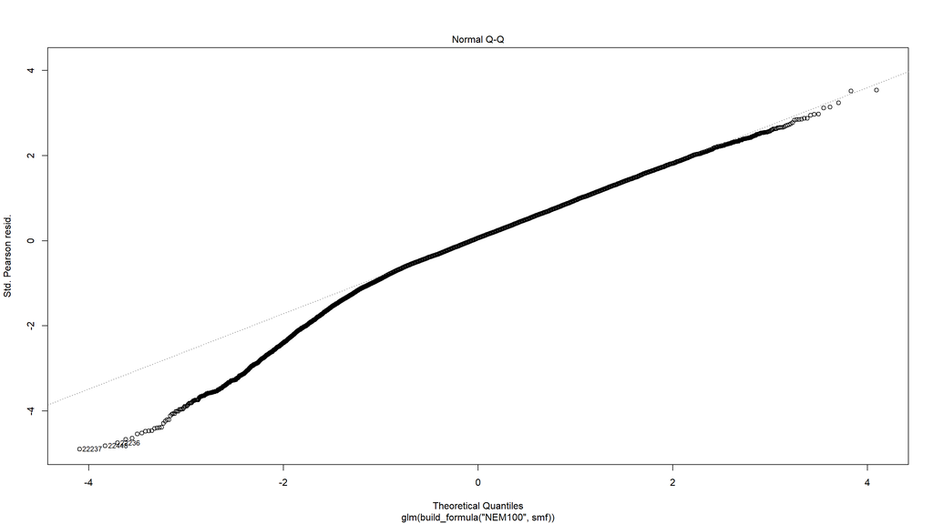

On constante une influence globale **négative** du nombre de 1/4 d’heures de trajets à une usine sur le `NEM100` *quand elle est **statistiquement siginficative***, **sauf pour les courtes durées**. On constante que s’éloigner de la mine diminue globalement le niveau d’équipement, mais de façon non linéaire selon les 1/4 d’heures. Le fait que les poids des 1/4 d’heures de trajets ne soient **pas décroissant** témoigne soit :

- d’une limite de ce facteur,
- d’une répartition hétérogène *en anneaux*, ce qui semble en cohérence avec l’analyse entre `MINE` et `DUREE_QUART` précédente (test du chi carré).

Les poids non ordonnés des durées de trajets est un phénomène attendu vue l’analyse précédente par AFC où les déciles du NEM étaient bien ordonnés mais pas les durées de trajet. Les grandes durées de trajets correspondent de plus à des zones de la côte est, plutôt au nord.

Si on les ajoute, on trouve aussi une influence positive de :

- du groupe d’âge décennal (`AGER_`) aussi (référence `[10,20[`, soit entre 10 et 20 ans),
- du travail dans le secteur nickel (`MINE`) (référence `FALSE`),

```
##        dev        dof dev_by_dof     dev_pc
##   5.38e+06   2.50e+01   2.15e+05   3.63e+01
```

Une variation de 5.376^{6} avec 25 soit 2.151^{5} déviation par degré de liberté du modèle qui représente au total 36.348% de la déviation.

On refait la même chose, mais cette fois avec un modèle **sans** prendre en compte la durée du trajet à la MINE :

```
##
## Call:
## glm(formula = build_formula("NEM100", setdiff(factors, c("AGER_",
##     "MINE_"))), data = bl19_desserte)
##
## Deviance Residuals:
##    Min      1Q  Median      3Q     Max
## -96.49  -11.16    1.21   13.45   66.41
##
## Coefficients:
##                                           Estimate Std. Error t value Pr(>|t|)
## (Intercept)                                 75.733      0.490  154.69  < 2e-16 ***
## DIPLR_CEP                                    2.253      0.873    2.58   0.0098 **
## DIPLR_BEPC                                   4.189      0.576    7.28  3.5e-13 ***
## DIPLR_CAP/BEP                                3.778      0.377   10.02  < 2e-16 ***
## DIPLR_Bac général                            8.809      0.545   16.17  < 2e-16 ***
## DIPLR_Bac tech./pro.                         6.207      0.499   12.44  < 2e-16 ***
## DIPLR_Bac+2/+3                              11.309      0.587   19.26  < 2e-16 ***
## DIPLR_Bac+5/+8                              11.435      0.587   19.48  < 2e-16 ***
## CS8_Artisans, commerçants et chefs d'ent.   14.013      0.656   21.36  < 2e-16 ***
## CS8_Cadres et professions int. sup.         15.851      0.795   19.95  < 2e-16 ***
## CS8_Professions intermédiaires              12.272      0.598   20.53  < 2e-16 ***
## CS8_Employés                                 8.861      0.545   16.25  < 2e-16 ***
## CS8_Ouvriers                                 7.266      0.515   14.10  < 2e-16 ***
## ETHAutre                                    16.418      0.497   33.05  < 2e-16 ***
## ETHEuropéenne/Calédonienne                  24.988      0.370   67.59  < 2e-16 ***
## ETHMétis                                    16.114      0.448   36.01  < 2e-16 ***
## ETHWallisienne/Futunienne                   16.930      0.952   17.79  < 2e-16 ***
## ---
## Signif. codes:  0 '***' 0.001 '**' 0.01 '*' 0.05 '.' 0.1 ' ' 1
##
## (Dispersion parameter for gaussian family taken to be 421)
##
##     Null deviance: 14791142  on 23578  degrees of freedom
## Residual deviance:  9912376  on 23562  degrees of freedom
## AIC: 209395
##
## Number of Fisher Scoring iterations: 2
```

```
##        dev        dof dev_by_dof     dev_pc
##    4878766         16     304923         33
```

On fait un test d’analyse de la variance pour comparer les deux modèles

```
## Analysis of Deviance Table
##
## Model 1: NEM100 ~ DIPLR_ + CS8_ + ETH
## Model 2: NEM100 ~ DIPLR_ + CS8_ + ETH + DUREE_USINE_QUART
##   Resid. Df Resid. Dev Df Deviance Pr(>Chi)
## 1     23562    9912376
## 2     23553    9414865  9   497511   <2e-16 ***
## ---
## Signif. codes:  0 '***' 0.001 '**' 0.01 '*' 0.05 '.' 0.1 ' ' 1
```

### Modèle des facteurs pairs à pair

On reprend la même chose, mais cette fois-ci avec les paires de facteurs et leurs intéractions croisées

```
## [1] "DIPLR_" "AGER_"
##        dev        dof dev_by_dof     dev_pc
##   2.63e+06   5.50e+01   4.77e+04   1.78e+01
## [1] "DIPLR_" "CS8_"
##        dev        dof dev_by_dof     dev_pc
##   2.72e+06   4.70e+01   5.78e+04   1.84e+01
## [1] "DIPLR_" "MINE_"
##        dev        dof dev_by_dof     dev_pc
##    2063800         15     137587         14
## [1] "DIPLR_" "ETH"
##        dev        dof dev_by_dof     dev_pc
##   4.66e+06   3.90e+01   1.19e+05   3.15e+01
## [1] "DIPLR_"            "DUREE_USINE_QUART"
##        dev        dof dev_by_dof     dev_pc
##   3.46e+06   7.90e+01   4.38e+04   2.34e+01
## [1] "AGER_" "CS8_"
##        dev        dof dev_by_dof     dev_pc
##    2071289         41      50519         14
## [1] "AGER_" "MINE_"
##        dev        dof dev_by_dof     dev_pc
##   2.72e+05   1.30e+01   2.09e+04   1.84e+00
## [1] "AGER_" "ETH"
##        dev        dof dev_by_dof     dev_pc
##   4.13e+06   3.40e+01   1.21e+05   2.79e+01
## [1] "AGER_"             "DUREE_USINE_QUART"
##        dev        dof dev_by_dof     dev_pc
##   2.45e+06   6.80e+01   3.60e+04   1.65e+01
## [1] "CS8_"  "MINE_"
##        dev        dof dev_by_dof     dev_pc
##   1.87e+06   1.00e+01   1.87e+05   1.26e+01
## [1] "CS8_" "ETH"
##        dev        dof dev_by_dof     dev_pc
##   4.70e+06   2.90e+01   1.62e+05   3.17e+01
## [1] "CS8_"              "DUREE_USINE_QUART"
##        dev        dof dev_by_dof     dev_pc
##   3.42e+06   5.80e+01   5.90e+04   2.31e+01
## [1] "MINE_" "ETH"
##        dev        dof dev_by_dof     dev_pc
##   4.02e+06   9.00e+00   4.47e+05   2.72e+01
## [1] "MINE_"             "DUREE_USINE_QUART"
##        dev        dof dev_by_dof     dev_pc
##   2.19e+06   1.90e+01   1.15e+05   1.48e+01
## [1] "ETH"               "DUREE_USINE_QUART"
##        dev        dof dev_by_dof     dev_pc
##   4.84e+06   4.70e+01   1.03e+05   3.27e+01
```

On retient ici l’interaction entre ethnie et durée de trajet à l’usine et les autres facteurs indépendant.

```
##
## Call:
## glm(formula = "NEM100 ~ ETH * DUREE_USINE_QUART + CS8_ + DIPLR_ ",
##     data = bl19_desserte)
##
## Deviance Residuals:
##    Min      1Q  Median      3Q     Max
## -99.54  -10.78    1.27   13.01   70.27
##
## Coefficients: (2 not defined because of singularities)
##                                                       Estimate Std. Error t value Pr(>|t|)
## (Intercept)                                             82.627      1.146   72.13  < 2e-16 ***
## ETHAutre                                                16.746      2.189    7.65  2.1e-14 ***
## ETHEuropéenne/Calédonienne                              20.252      2.106    9.62  < 2e-16 ***
## ETHMétis                                                11.220      2.372    4.73  2.3e-06 ***
## ETHWallisienne/Futunienne                               19.594      4.944    3.96  7.4e-05 ***
## DUREE_USINE_QUART[015,030[                               6.159      1.161    5.30  1.1e-07 ***
## DUREE_USINE_QUART[030,045[                              -6.271      1.187   -5.28  1.3e-07 ***
## DUREE_USINE_QUART[045,060[                              -0.369      1.231   -0.30   0.7641
## DUREE_USINE_QUART[060,075[                              -7.007      1.184   -5.92  3.3e-09 ***
## DUREE_USINE_QUART[075,090[                              -6.689      1.122   -5.96  2.5e-09 ***
## DUREE_USINE_QUART[090,105[                              -4.068      1.296   -3.14   0.0017 **
## DUREE_USINE_QUART[105,120[                             -10.753      1.130   -9.52  < 2e-16 ***
## DUREE_USINE_QUART[120,135[                              -6.825      1.163   -5.87  4.4e-09 ***
## DUREE_USINE_QUART[135,150[                             -22.990      3.128   -7.35  2.1e-13 ***
## CS8_Artisans, commerçants et chefs d'ent.               12.755      0.641   19.91  < 2e-16 ***
## CS8_Cadres et professions int. sup.                     13.429      0.779   17.24  < 2e-16 ***
## CS8_Professions intermédiaires                          10.842      0.585   18.54  < 2e-16 ***
## CS8_Employés                                             7.754      0.534   14.51  < 2e-16 ***
## CS8_Ouvriers                                             5.977      0.507   11.80  < 2e-16 ***
## DIPLR_CEP                                                1.987      0.848    2.34   0.0192 *
## DIPLR_BEPC                                               3.288      0.560    5.87  4.4e-09 ***
## DIPLR_CAP/BEP                                            3.232      0.367    8.81  < 2e-16 ***
## DIPLR_Bac général                                        7.615      0.531   14.34  < 2e-16 ***
## DIPLR_Bac tech./pro.                                     4.775      0.487    9.80  < 2e-16 ***
## DIPLR_Bac+2/+3                                           9.216      0.574   16.06  < 2e-16 ***
## DIPLR_Bac+5/+8                                           9.510      0.575   16.54  < 2e-16 ***
## ETHAutre:DUREE_USINE_QUART[015,030[                     -1.706      2.411   -0.71   0.4793
## ETHEuropéenne/Calédonienne:DUREE_USINE_QUART[015,030[   -2.997      2.231   -1.34   0.1793
## ETHMétis:DUREE_USINE_QUART[015,030[                      0.350      2.556    0.14   0.8910
```

[output cut: 28 more lines]

```
## ETHWallisienne/Futunienne:DUREE_USINE_QUART[120,135[    -4.667      7.598   -0.61   0.5391
## ETHAutre:DUREE_USINE_QUART[135,150[                     -9.565      9.636   -0.99   0.3209
## ETHEuropéenne/Calédonienne:DUREE_USINE_QUART[135,150[       NA         NA      NA       NA
## ETHMétis:DUREE_USINE_QUART[135,150[                     26.802     20.273    1.32   0.1862
## ETHWallisienne/Futunienne:DUREE_USINE_QUART[135,150[        NA         NA      NA       NA
## ---
## Signif. codes:  0 '***' 0.001 '**' 0.01 '*' 0.05 '.' 0.1 ' ' 1
##
## (Dispersion parameter for gaussian family taken to be 396)
##
##     Null deviance: 14791142  on 23578  degrees of freedom
## Residual deviance:  9325174  on 23519  degrees of freedom
## AIC: 208041
##
## Number of Fisher Scoring iterations: 2
```

```
##        dev        dof dev_by_dof     dev_pc
##    5465967         59      92644         37
```

On peut prendre un modèle plus riche, mais à un prix qui devient élevé en temps de calcul et en nombre de degrés de liberté : on touche les limites possibles avec ces facteurs.

```
##        dev        dof dev_by_dof     dev_pc
##   5.74e+06   1.42e+02   4.04e+04   3.88e+01
```